# Oman methane stable isotope data processing and plotting

Source file: 200228_DBN_Oman_CH4_paper_figs.Rmd

Daniel Nothaft

03 May 2021

# 1 Setup

## 1.1 Load code libraries

```r
# load libraries
library(tidyverse) # dplyr, tidyr, ggplot
library(openxlsx) # reading and writing excel file
library(plotly) # interactive plots
library(knitr) # generating reports
library(scales) # making log scales with exponents
library(ggrepel) # algorithm to avoid overlapping labels
library(cowplot) # extracting legends from plots

# global knitting options for automatic saving of all plots as .png and .pdf
knitr::opts_chunk$set(
  dev = c("png", "pdf"), fig.keep = "all",
  dev.args = list(pdf = list(encoding = "WinAnsi", useDingbats = FALSE)),
  fig.path = file.path("fig_output/", paste0(gsub("\\.[Rr]md", "/", knitr::current_input()))),
  cache.path = file.path("cache/", paste0(gsub("\\.[Rr]md", "/", knitr::current_input())))
)
```

## 1.2 Load data

Load in Oman well data

```r
# Load in Oman aqueous geochemistry etc.
data <- read.xlsx("data_raw/Summary_metadata/Oman_Geochem_2012-2018.xlsx") # read in data from excel file

# add site column for plotting against other literature data
data <- data %>% mutate(site = "Oman/UAE")

# print data
data
```

| sampling_site | year_sampled | month_sampled | day_sampled | depth_fluid_intake_mbct | notes | sampling_method | upper_packer_inflated | upper_packer_depth_mbct | lower_packer_inflated | lower_packer_depth_mbct | well_depth_mbgl | casing_extent_mbct | casing_height_magl | screened_interval_mbct | depth_to_water_mbct | first_publication_author | first_publication_year | first_publication_title | water_type | UTM_Easting_40N | UTM_Northing_40N | lat_deg_N_WGS84 | long_deg_E_WGS84 | elevation_masl | pH | temp_C | conductivity_uS_cm | Eh_mV | Na_total_uM | … |
| --- | --- | --- | --- | --- | --- | --- | --- | --- | --- | --- | --- | --- | --- | --- | --- | --- | --- | --- | --- | --- | --- | --- | --- | --- | --- | --- | --- | --- | --- | --- |
| CM2A | 2018 | 2 | 9 | 75.0 | NA | open borehole pumping - Grundfos submersible | NA | NA | NA | NA | 400.0 | 23.7 | 1 | open below casing | 13.40 | NA | NA | NA | Ca_OH | 636988 | 2534284 | 22.91095 | 58.33575 | 713 | 11.320 | 33.60 | 2860.0 | NA | 20677.2748 | … |
| NSHQ04 | 2018 | 2 | 3 | 8.0 | NA | open borehole pumping - Typhoon submersible, Proactive Env. Products | NA | NA | NA | NA | 304.0 | 5.8 | 1 | open below casing | 4.70 | NA | NA | NA | Ca_OH | 670971 | 2531699 | 22.88448 | 58.66673 | 543 | NA | 33.40 | 3350.0 | -174.0 | NA | … |
| NSHQ14 | 2018 | 2 | 6 | 85.0 | NA | open borehole pumping - Grundfos submersible | NA | NA | NA | NA | 304.0 | 5.8 | 1 | open below casing | 9.20 | NA | NA | NA | Ca_OH | 675495 | 2529716 | 22.86611 | 58.71059 | 526 | 11.390 | 36.70 | 2665.0 | NA | 10311.6962 | … |
| WAB103 | 2018 | 2 | 9 | 70.0 | NA | open borehole pumping - Grundfos submersible | NA | NA | NA | NA | 101.0 | 101.0 | 1 | 90-98 | 15.00 | NA | NA | NA | gabbro | 648577 | 2530362 | 22.87454 | 58.44835 | 632 | 8.510 | 34.90 | 1405.0 | NA | 1176.7796 | … |
| WAB104 | 2018 | 2 | 5 | 85.0 | NA | open borehole pumping - Grundfos submersible | NA | NA | NA | NA | 120.4 | 120.4 | 1 | 100.8-104 | 40.00 | NA | NA | NA | Mg_HCO3 | 643099 | 2541124 | 22.97221 | 58.39596 | 842 | 8.790 | 33.70 | 548.0 | 133.0 | 753.3049 | … |
| WAB105 | 2018 | 2 | 5 | 60.0 | NA | open borehole pumping - Grundfos submersible | NA | NA | NA | NA | 120.5 | 120.5 | 1 | 110-117 | 16.50 | NA | NA | NA | Mg_HCO3 | 644678 | 2536524 | 22.93053 | 58.41093 | 738 | 8.660 | 33.70 | 498.0 | 162.0 | 1176.7796 | … |
| WAB188 | 2018 | 2 | 8 | 50.0 | NA | open borehole pumping - Grundfos submersible | NA | NA | NA | NA | 78.0 | 78.0 | 1 | 34.5-51 | 9.50 | NA | NA | NA | gabbro | 671123 | 2529798 | 22.86730 | 58.66800 | 514 | 8.160 | 35.60 | 1116.0 | NA | 4061.7538 | … |
| WAB55 | 2018 | 2 | 7 | 50.0 | NA | open borehole pumping - Grundfos submersible | NA | NA | NA | NA | 102.0 | 102.0 | 1 | 8-97 | 7.50 | NA | NA | NA | Mg_HCO3 | 634777 | 2506101 | 22.65660 | 58.31176 | 531 | 9.620 | 36.20 | 1183.0 | NA | 4442.5574 | … |
| WAB71 | 2018 | 2 | 3 | 70.0 | NA | bailer / open borehole pumping | NA | NA | NA | NA | 136.5 | 136.5 | 1 | 128-131 | 8.30 | NA | NA | NA | Ca_OH | 670322 | 2533981 | 22.90515 | 58.66066 | 608 | 11.220 | 34.90 | 1973.0 | -229.0 | 6253.8677 | … |
| NSHQ04 | 2017 | 2 | 24 | 5.8 | NA | open borehole pumping - Typhoon submersible, Proactive Env. Products | NA | NA | NA | NA | 304.0 | 5.8 | 1 | open below casing | 5.18 | NA | NA | NA | Ca_OH | 670971 | 2531699 | 22.88448 | 58.66673 | 543 | 10.000 | NA | NA | NA | 10400.0000 | … |

[output cut: 37 more lines]

Load in comparison data from the literature

```r
# read comparison data from literature
data_literature <- read.xlsx("data_raw/Summary_metadata/CH4_isotope_literature_data.xlsx")

# print
data_literature
```

|  | site | site_2 | locality | author | year_published | title_of_publication | year_sampled | ID | Sample | sample_type | Lithology | Technician | gas_conc_unit | CH4_conc | CH4_was_measured | CH4_LQ | C2H6_conc | C2H6_was_measured | C2H6_LQ | C3H8_conc | C3H8_was_measured | C3H8_LQ | n_C4H10_conc | n_C4H10_was_measured | n_C4H10_LQ | n_C5H12_conc | n_C5H12_was_measured | n_C5H12_LQ | CH4_d13C_permil_VPDB | … |
| --- | --- | --- | --- | --- | --- | --- | --- | --- | --- | --- | --- | --- | --- | --- | --- | --- | --- | --- | --- | --- | --- | --- | --- | --- | --- | --- | --- | --- | --- | --- |
| 1 | Philippines | Luzon | Los Fuegos Eternos | Abrajano et al. | 1990 | Geochemistry of reduced gas related to serpentinization of the Zambales ophiolite, Philippines | NA | NA | LFE-1 | vent/well fluid | peridotite | NA | ppmv | 130000.0 | TRUE | NA | 4.000e+02 | TRUE | NA | NA | FALSE | NA | NA | FALSE | NA | NA | FALSE | NA | -7.100 | … |
| 2 | Philippines | Luzon | Los Fuegos Eternos | Abrajano et al. | 1990 | Geochemistry of reduced gas related to serpentinization of the Zambales ophiolite, Philippines | NA | NA | LFE-2 | vent/well fluid | peridotite | NA | ppmv | 553000.0 | TRUE | NA | 1.500e+03 | TRUE | NA | NA | FALSE | NA | NA | FALSE | NA | NA | FALSE | NA | -7.420 | … |
| 3 | Philippines | Luzon | Los Fuegos Eternos | Abrajano et al. | 1990 | Geochemistry of reduced gas related to serpentinization of the Zambales ophiolite, Philippines | NA | NA | LFE-3 | vent/well fluid | peridotite | NA | ppmv | 548000.0 | TRUE | NA | 1.200e+03 | TRUE | NA | NA | FALSE | NA | NA | FALSE | NA | NA | FALSE | NA | -6.520 | … |
| 4 | Oman/UAE | Oman | Bahla | Boulart et al. | 2013 | Differences in gas venting from ultramafic-hosted warm springs : the example of Oman and Voltri Ophiolites | 2011 | 11 | NA | vent/well fluid | Serpentinite | NA | ppmv | 15000.0 | TRUE | NA | 6.960e+01 | TRUE | NA | 1.50e+01 | TRUE | NA | 4.4e+00 | TRUE | NA | NA | TRUE | NA | NA | … |
| 5 | Oman/UAE | Oman | Bahla | Boulart et al. | 2013 | Differences in gas venting from ultramafic-hosted warm springs : the example of Oman and Voltri Ophiolites | 2011 | 11 | NA | vent/well fluid | Serpentinite | NA | ppmv | 16000.0 | TRUE | NA | 7.030e+01 | TRUE | NA | 1.47e+01 | TRUE | NA | 5.2e+00 | TRUE | NA | NA | TRUE | NA | NA | … |
| 6 | Oman/UAE | Oman | Bahla | Boulart et al. | 2013 | Differences in gas venting from ultramafic-hosted warm springs : the example of Oman and Voltri Ophiolites | 2011 | 11 | NA | vent/well fluid | Serpentinite | NA | ppmv | 25000.0 | TRUE | NA | 7.070e+01 | TRUE | NA | 1.49e+01 | TRUE | NA | 5.8e+00 | TRUE | NA | NA | TRUE | NA | NA | … |
| 7 | Oman/UAE | Oman | Miskin | Boulart et al. | 2013 | Differences in gas venting from ultramafic-hosted warm springs : the example of Oman and Voltri Ophiolites | 2011 | 13 | NA | vent/well fluid | peridotite/gabbro, MOHO | NA | ppmv | 15000.0 | TRUE | NA | 9.900e+00 | TRUE | NA | 8.20e+00 | TRUE | NA | NA | TRUE | NA | NA | TRUE | NA | NA | … |
| 8 | Oman/UAE | Oman | Miskin | Boulart et al. | 2013 | Differences in gas venting from ultramafic-hosted warm springs : the example of Oman and Voltri Ophiolites | 2011 | 13 | NA | vent/well fluid | peridotite/gabbro, MOHO | NA | ppmv | 15000.0 | TRUE | NA | 9.500e+00 | TRUE | NA | 7.80e+00 | TRUE | NA | 5.7e+00 | TRUE | NA | 8.2 | TRUE | NA | NA | … |
| 9 | Oman/UAE | Oman | Haylan | Boulart et al. | 2013 | Differences in gas venting from ultramafic-hosted warm springs : the example of Oman and Voltri Ophiolites | 2011 | 20 | NA | vent/well fluid | bedded gabbro above peridotite (100 m thick) | NA | ppmv | 56000.0 | TRUE | NA | 1.010e+01 | TRUE | NA | NA | TRUE | NA | NA | TRUE | NA | NA | TRUE | NA | NA | … |
| 10 | Oman/UAE | Oman | Haylan | Boulart et al. | 2013 | Differences in gas venting from ultramafic-hosted warm springs : the example of Oman and Voltri Ophiolites | 2011 | 20 | NA | vent/well fluid | bedded gabbro above peridotite (100 m thick) | NA | ppmv | 55000.0 | TRUE | NA | 1.120e+01 | TRUE | NA | NA | TRUE | NA | NA | TRUE | NA | NA | TRUE | NA | NA | … |

[output cut: 123 more lines]

## 1.3 Set plotting aesthetics

```r
# colors

microbial_color <- "#009E73" # forest/mint green
thermogenic_color <- "#F0E442" # yellow
abiotic_color <- "#999999" # grey

microbial_opacity <- 0.05
thermo_opacity <- 0.1
abiotic_opacity <- 0.08

gabbro_color <- "#CC79A7" # magenta
Mg_HCO3_color <- "#E69F00" # gold
Ca_OH_color <- "#0072B2" # dark blue

cbPalette_water_types <- c(gabbro_color, Mg_HCO3_color, Ca_OH_color)
names(cbPalette_water_types) <- c("gabbro", "Mg_HCO3", "Ca_OH")

cbPalette_MWL <- c("#D55E00", "#0072B2", "#000000")

color_rock_crush_named <- c("rock crushing" = "#D55E00", "vent/well fluid" = "black")

color_TF <- c("TRUE" = "black", "FALSE" = gray(0, 0.15))

fill_4_wells_named <- c("WAB71" = "#999999", "NSHQ14" = "#000000", "NSHQ04" = "#56B4E9", "CM2A" = "#0072B2")

# levels (for order of appearance in legend)

data_literature$site <- factor(data_literature$site, levels = c("Oman/UAE", "Philippines", "Mid-Cayman Rise", "Lost City", "Ashadze II", "Kidd Creek", "Sabatier reaction 70˚C to 90˚C"))

# shapes

shapes_all_sites_named <- c("Oman/UAE" = 21, "Philippines" = 0, "Mid-Cayman Rise" = 2,  "Ashadze II" = 6, "Kidd Creek" = 4, "Sabatier reaction 70˚C to 90˚C" = 3, "Lost City" = 5)

shapes_fills <- c(22, 23, 24, 21)
```

# 2 Water stable isotopes plot

## 2.1 Get and summarize water stable isotope data

```r
# select water isotope data from full dataset
data_water_isotopes <- data %>% filter(!is.na(H2O_dD_permil_VSMOW)) %>% select(sampling_site, year_sampled, H2O_dD_permil_VSMOW, H2O_d18O_permil_VSMOW)

# print
data_water_isotopes
```

| sampling_site | year_sampled | H2O_dD_permil_VSMOW | H2O_d18O_permil_VSMOW |
| --- | --- | --- | --- |
| CM2A | 2018 | 1.70 | 0.67 |
| NSHQ14 | 2018 | 0.20 | 0.43 |
| WAB103 | 2018 | -0.50 | 0.34 |
| WAB104 | 2018 | -0.50 | -0.53 |
| WAB105 | 2018 | 4.00 | 0.50 |
| WAB188 | 2018 | -2.10 | -0.71 |
| WAB55 | 2018 | 2.20 | 0.26 |
| WAB71 | 2018 | -3.00 | -0.40 |
| NSHQ04 | 2014 | -15.00 | -3.00 |
| NSHQ14 | 2014 | 2.00 | 0.70 |

[output cut: 4 more lines]

Summarize water stable isotope data by well and year

```r
# group water isotope data by well and sample year and compute summary data
data_water_isotopes_summ_well_year <- data_water_isotopes %>% group_by(sampling_site, year_sampled) %>% summarize(n = n(), H2O_dD_permil_VSMOW_mean_well_year = mean(H2O_dD_permil_VSMOW), H2O_dD_permil_VSMOW_sd = sd(H2O_dD_permil_VSMOW), H2O_d18O_permil_VSMOW_mean_well_year = mean(H2O_d18O_permil_VSMOW), H2O_d18O_permil_VSMOW_sd = sd(H2O_d18O_permil_VSMOW))
# print
data_water_isotopes_summ_well_year
```

| sampling_site | year_sampled | n | H2O_dD_permil_VSMOW_mean_well_year | H2O_dD_permil_VSMOW_sd | H2O_d18O_permil_VSMOW_mean_well_year | H2O_d18O_permil_VSMOW_sd |
| --- | --- | --- | --- | --- | --- | --- |
| CM2A | 2018 | 1 | 1.7000000 | NA | 0.6700000 | NA |
| NSHQ04 | 2012 | 1 | -6.2700000 | NA | -1.9200000 | NA |
| NSHQ04 | 2014 | 1 | -15.0000000 | NA | -3.0000000 | NA |
| NSHQ14 | 2012 | 3 | -0.2166667 | 0.2367136 | 0.3866667 | 0.04041452 |
| NSHQ14 | 2014 | 1 | 2.0000000 | NA | 0.7000000 | NA |
| NSHQ14 | 2018 | 1 | 0.2000000 | NA | 0.4300000 | NA |
| WAB103 | 2018 | 1 | -0.5000000 | NA | 0.3400000 | NA |
| WAB104 | 2018 | 1 | -0.5000000 | NA | -0.5300000 | NA |
| WAB105 | 2018 | 1 | 4.0000000 | NA | 0.5000000 | NA |
| WAB188 | 2018 | 1 | -2.1000000 | NA | -0.7100000 | NA |

[output cut: 2 more lines]

Summarize water stable isotope data by well

```r
# group water data computed in previous chunk by well and compute summary data
data_water_isotopes_summ_well <- data_water_isotopes_summ_well_year  %>% group_by(sampling_site) %>% summarize(n = n(), H2O_dD_permil_VSMOW_mean_well = mean(H2O_dD_permil_VSMOW_mean_well_year), H2O_dD_permil_VSMOW_sd = sd(H2O_dD_permil_VSMOW_mean_well_year), H2O_d18O_permil_VSMOW_mean_well = mean(H2O_d18O_permil_VSMOW_mean_well_year), H2O_d18O_permil_VSMOW_sd = sd(H2O_d18O_permil_VSMOW_mean_well_year))
# print
data_water_isotopes_summ_well
```

| sampling_site | n | H2O_dD_permil_VSMOW_mean_well | H2O_dD_permil_VSMOW_sd | H2O_d18O_permil_VSMOW_mean_well | H2O_d18O_permil_VSMOW_sd |
| --- | --- | --- | --- | --- | --- |
| CM2A | 1 | 1.7000000 | NA | 0.6700000 | NA |
| NSHQ04 | 2 | -10.6350000 | 6.173042 | -2.4600000 | 0.7636753 |
| NSHQ14 | 3 | 0.6611111 | 1.178079 | 0.5055556 | 0.1697820 |
| WAB103 | 1 | -0.5000000 | NA | 0.3400000 | NA |
| WAB104 | 1 | -0.5000000 | NA | -0.5300000 | NA |
| WAB105 | 1 | 4.0000000 | NA | 0.5000000 | NA |
| WAB188 | 1 | -2.1000000 | NA | -0.7100000 | NA |
| WAB55 | 1 | 2.2000000 | NA | 0.2600000 | NA |
| WAB71 | 1 | -3.0000000 | NA | -0.4000000 | NA |

Summarize all water stable isotope

```r
# summarize water isotope data from all wells
data_water_isotopes_summ <- data_water_isotopes_summ_well %>% ungroup() %>% summarize(n = n(), H2O_dD_permil_VSMOW_mean = mean(H2O_dD_permil_VSMOW_mean_well), H2O_dD_permil_VSMOW_sd = sd(H2O_dD_permil_VSMOW_mean_well), H2O_d18O_permil_VSMOW_mean = mean(H2O_d18O_permil_VSMOW_mean_well), H2O_d18O_permil_VSMOW_sd = sd(H2O_d18O_permil_VSMOW_mean_well))

# print
data_water_isotopes_summ
```

| n | H2O_dD_permil_VSMOW_mean | H2O_dD_permil_VSMOW_sd | H2O_d18O_permil_VSMOW_mean | H2O_d18O_permil_VSMOW_sd |
| --- | --- | --- | --- | --- |
| 9 | -0.9082099 | 4.239055 | -0.202716 | 0.9851676 |

## 2.2 Plot water stable isotope data

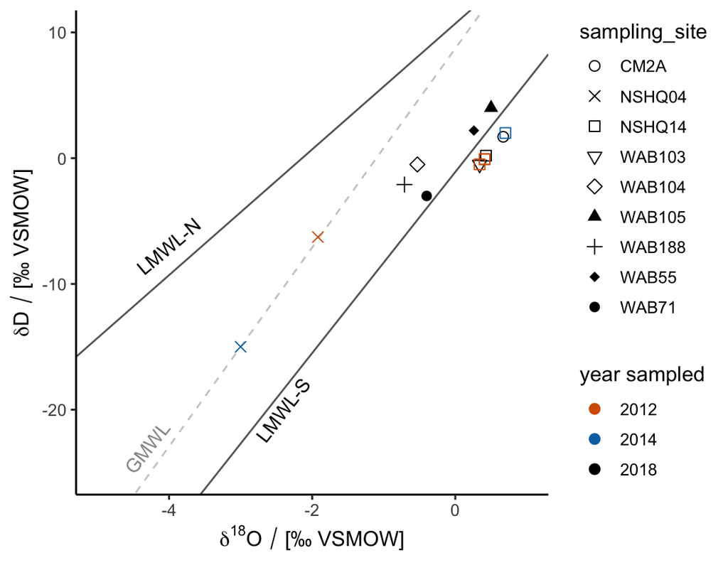

```r
# create plot
MWL_plot <- data_water_isotopes %>% ggplot() +

  # add meteoric water lines
  geom_abline(slope = 7.91, intercept = 8.72, color = "grey80", linetype = "dashed") + # GMWL, Terzer et al. 2013
  annotate("text", label = "GMWL", x = -4.3, y = -23, angle = 52, color = "grey60") +
  geom_abline(slope = 5.0, intercept = 10.7, color = "grey40") + # LMWL-N
  annotate("text", label = "LMWL-N", x = -4, y = -7, angle = 40) +
  geom_abline(slope = 7.2, intercept = -1.1, color = "grey40") + # LMWL-S
  annotate("text", label = "LMWL-S", x = -2.4, y = -20, angle = 52) +

  # plot Oman well data
  geom_point(aes(
  x = H2O_d18O_permil_VSMOW,
  y = H2O_dD_permil_VSMOW,
  color = as.character(year_sampled),
  shape = sampling_site
  ), size = 2.5, alpha = 1) +

  # symbol styling
  scale_shape_manual(values=c(1, 4, 0, 6, 5, 17, 3, 18, 16), guide = guide_legend(order = 1))+
  scale_color_manual(values = cbPalette_MWL, name = "year sampled", guide = guide_legend(order = 2)) +

  # axis styling
  scale_x_continuous(limits = c(-5, 1), name = latex2exp::TeX("$\\delta^{18}O\\, /\\, \\[\U2030  \\, VSMOW \\]$")) +
  scale_y_continuous(limits = c(-25, 10), name = latex2exp::TeX("$\\delta D\\, /\\, \\[\U2030  \\, VSMOW \\]$")) +

  # design
  theme_classic(base_size = 12)

# print plot
MWL_plot
```

# 3 Summary of $\delta^{13}\text{C}_{\text{CH}_4}$, $\delta\text{D}_{\text{CH}_4}$ and $c_{\Sigma{\text{CO}_2}}$ data

```r
# make data frame of CH4 d13C and dD data for all wells
data_CD <- data %>% select(sampling_site, year_sampled, depth_fluid_intake_mbct, water_type, CH4_d13C_permil_VPDB_LBNL, CH4_dD_permil_VSMOW_LBNL,
CH4_d13C_permil_VPDB_CUB, CH4_dD_permil_VSMOW_CUB, CH4_d13C_permil_VPDB_MIT, CH4_dD_permil_VSMOW_MIT, CH4_d13C_permil_VPDB_UCLA, CH4_dD_permil_VSMOW_UCLA, site)

# compute means between analyses in multiple labs
data_CD <- data_CD %>%
    rowwise() %>%
    mutate(CH4_d13C_permil_VPDB_interlab_mean  = mean(c(CH4_d13C_permil_VPDB_LBNL, CH4_d13C_permil_VPDB_CUB, CH4_d13C_permil_VPDB_MIT, CH4_d13C_permil_VPDB_UCLA), na.rm = TRUE))

data_CD <- data_CD %>%
    rowwise() %>%
    mutate(CH4_dD_permil_VSMOW_interlab_mean  = mean(c(CH4_dD_permil_VSMOW_LBNL, CH4_dD_permil_VSMOW_CUB, CH4_dD_permil_VSMOW_MIT, CH4_dD_permil_VSMOW_UCLA), na.rm = TRUE))

# remove samples without C and D isotope data
data_CD <- data_CD %>% filter(!is.nan(CH4_d13C_permil_VPDB_interlab_mean) & !is.nan(CH4_dD_permil_VSMOW_interlab_mean))

# print
data_CD %>% select(sampling_site, year_sampled, CH4_d13C_permil_VPDB_interlab_mean, CH4_dD_permil_VSMOW_interlab_mean)
```

| sampling_site | year_sampled | CH4_d13C_permil_VPDB_interlab_mean | CH4_dD_permil_VSMOW_interlab_mean |
| --- | --- | --- | --- |
| CM2A | 2018 | -4.280000 | -198.0167 |
| NSHQ04 | 2018 | 4.438500 | -228.1980 |
| NSHQ14 | 2018 | -3.557333 | -306.4367 |
| WAB71 | 2018 | 3.600000 | -307.0000 |
| NSHQ04 | 2017 | 5.195000 | -227.3350 |
| NSHQ14 | 2017 | 0.060000 | -269.9100 |
| WAB71 | 2017 | 3.900000 | -313.0000 |
| NSHQ14 | 2016 | -2.545000 | -290.7600 |
| NSHQ04 | 2015 | 1.200000 | -219.5000 |
| NSHQ04 | 2014 | 2.400000 | -205.0000 |

[output cut: 1 more lines]

Summarize WAB188 $\delta^{13}\text{C}_{\text{CH}_4}$ data

```r
# make data frame of relevant data
data_WAB188 <- data %>% filter(sampling_site == "WAB188") %>%  filter(!is.na(CH4_d13C_permil_VPDB_LBNL) | !is.na(CH4_d13C_permil_VPDB_CUB)) %>% select(year_sampled, CH4_d13C_permil_VPDB_LBNL,
CH4_d13C_permil_VPDB_CUB)

# print
data_WAB188
```

| year_sampled | CH4_d13C_permil_VPDB_LBNL | CH4_d13C_permil_VPDB_CUB |
| --- | --- | --- |
| 2018 | NA | -86.7 |
| 2017 | NA | -60.8 |
| 2015 | -71.3 | NA |

```r
# make data frame of relevant data
data_WAB188 <- data_WAB188 %>% mutate(CH4_d13C_permil_VPDB = ifelse(!is.na(CH4_d13C_permil_VPDB_LBNL), CH4_d13C_permil_VPDB_LBNL, CH4_d13C_permil_VPDB_CUB))

# print
data_WAB188 %>% summarise(n = n(), mean_CH4_d13C_permil_VPDB = mean(CH4_d13C_permil_VPDB), sd_CH4_d13C_permil_VPDB = sd(CH4_d13C_permil_VPDB))
```

| n | mean_CH4_d13C_permil_VPDB | sd_CH4_d13C_permil_VPDB |
| --- | --- | --- |
| 3 | -72.93333 | 13.02702 |

Summarize WAB188 dissolved inorganic carbon data

```r
# make data frame of relevant data
data_WAB188_DIC <- data %>% filter(sampling_site == "WAB188") %>%  filter(DIC_was_measured == TRUE) %>% select(year_sampled, DIC_uM)

# print
data_WAB188_DIC
```

| year_sampled | DIC_uM |
| --- | --- |
| 2018 | 3480 |
| 2017 | 3000 |
| 2015 | 2250 |

```r
# summarize and print
data_WAB188_DIC %>% summarise(n = n(), mean_DIC_uM = mean(DIC_uM), sd_DIC_uM = sd(DIC_uM))
```

| n | mean_DIC_uM | sd_DIC_uM |
| --- | --- | --- |
| 3 | 2910 | 619.9193 |

Summarize WAB71 $\delta^{13}\text{C}_{\text{CH}_4}$ data

```r
# make data frame of relevant data
data_WAB71 <- data %>% filter(sampling_site == "WAB71") %>%  filter(!is.na(CH4_d13C_permil_VPDB_LBNL) | !is.na(CH4_d13C_permil_VPDB_CUB)) %>% select(year_sampled, CH4_d13C_permil_VPDB_LBNL,
CH4_d13C_permil_VPDB_CUB)

# print
data_WAB71
```

| year_sampled | CH4_d13C_permil_VPDB_LBNL | CH4_d13C_permil_VPDB_CUB |
| --- | --- | --- |
| 2018 | NA | 3.6 |
| 2017 | NA | 3.9 |
| 2016 | 3.00 | NA |
| 2015 | 2.85 | NA |

```r
# make data frame of relevant data
data_WAB71 <- data_WAB71 %>% mutate(CH4_d13C_permil_VPDB = ifelse(!is.na(CH4_d13C_permil_VPDB_LBNL), CH4_d13C_permil_VPDB_LBNL, CH4_d13C_permil_VPDB_CUB))

# print
data_WAB71 %>% summarise(n = n(), mean_CH4_d13C_permil_VPDB = mean(CH4_d13C_permil_VPDB), sd_CH4_d13C_permil_VPDB = sd(CH4_d13C_permil_VPDB))
```

| n | mean_CH4_d13C_permil_VPDB | sd_CH4_d13C_permil_VPDB |
| --- | --- | --- |
| 4 | 3.3375 | 0.4956057 |

Summarize CM2A $\delta^{13}\text{C}_{\text{CH}_4}$ data

```r
# make data frame of relevant data
data_CM2A <- data %>% filter(sampling_site == "CM2A") %>% select(CH4_d13C_permil_VPDB_CUB, CH4_d13C_permil_VPDB_MIT, CH4_d13C_permil_VPDB_UCLA)

# gather CH4 d13C across various labs
data_CM2A_gathered <- data_CM2A %>% gather(key = "lab", value = "CH4_d13C_permil_VPDB")

# print
data_CM2A_gathered
```

| lab | CH4_d13C_permil_VPDB |
| --- | --- |
| CH4_d13C_permil_VPDB_CUB | -4.30 |
| CH4_d13C_permil_VPDB_MIT | -3.83 |
| CH4_d13C_permil_VPDB_UCLA | -4.71 |

```r
# summarize and print
data_CM2A_gathered  %>% summarise(n = n(), mean_CH4_d13C_permil_VPDB = mean(CH4_d13C_permil_VPDB), sd_CH4_d13C_permil_VPDB = sd(CH4_d13C_permil_VPDB))
```

| n | mean_CH4_d13C_permil_VPDB | sd_CH4_d13C_permil_VPDB |
| --- | --- | --- |
| 3 | -4.28 | 0.4403408 |

All wells

```r
# compute means for each year for each well
data_CD_well_year_summ <- data_CD %>% group_by(sampling_site,year_sampled) %>% summarise(CH4_d13C_permil_VPDB_interlab_mean = mean(CH4_d13C_permil_VPDB_interlab_mean), CH4_dD_permil_VSMOW_interlab_mean = mean(CH4_dD_permil_VSMOW_interlab_mean), water_type = first(water_type))
# print
data_CD_well_year_summ
```

| sampling_site | year_sampled | CH4_d13C_permil_VPDB_interlab_mean | CH4_dD_permil_VSMOW_interlab_mean | water_type |
| --- | --- | --- | --- | --- |
| CM2A | 2018 | -4.280000 | -198.0167 | Ca_OH |
| NSHQ04 | 2014 | 2.400000 | -205.0000 | Ca_OH |
| NSHQ04 | 2015 | 1.200000 | -219.5000 | Ca_OH |
| NSHQ04 | 2017 | 5.195000 | -227.3350 | Ca_OH |
| NSHQ04 | 2018 | 4.438500 | -228.1980 | Ca_OH |
| NSHQ14 | 2014 | 3.000000 | -232.0000 | Ca_OH |
| NSHQ14 | 2016 | -2.545000 | -290.7600 | Ca_OH |
| NSHQ14 | 2017 | 0.060000 | -269.9100 | Ca_OH |
| NSHQ14 | 2018 | -3.557333 | -306.4367 | Ca_OH |
| WAB71 | 2017 | 3.900000 | -313.0000 | Ca_OH |

[output cut: 1 more lines]

```r
# compute means across years for each well
data_CD_well_summ <- data_CD %>% group_by(sampling_site) %>% summarise(CH4_d13C_permil_VPDB_interannual_mean = mean(CH4_d13C_permil_VPDB_interlab_mean), CH4_d13C_permil_VPDB_interannual_sd = sd(CH4_d13C_permil_VPDB_interlab_mean), CH4_dD_permil_VSMOW_interannual_mean = mean(CH4_dD_permil_VSMOW_interlab_mean), CH4_dD_permil_VSMOW_interannual_sd = sd(CH4_dD_permil_VSMOW_interlab_mean), n = n(), water_type = first(water_type))
# print
data_CD_well_summ
```

| sampling_site | CH4_d13C_permil_VPDB_interannual_mean | CH4_d13C_permil_VPDB_interannual_sd | CH4_dD_permil_VSMOW_interannual_mean | CH4_dD_permil_VSMOW_interannual_sd | n | water_type |
| --- | --- | --- | --- | --- | --- | --- |
| CM2A | -4.2800000 | NA | -198.0167 | NA | 1 | Ca_OH |
| NSHQ04 | 3.3083750 | 1.835477 | -220.0082 | 10.743357 | 4 | Ca_OH |
| NSHQ14 | -0.7605833 | 2.933786 | -274.7767 | 32.204297 | 4 | Ca_OH |
| WAB71 | 3.7500000 | 0.212132 | -310.0000 | 4.242641 | 2 | Ca_OH |

# 4 $c_{\text{CH}_4}$ vs. $c_{\text{H}_2}$ plot

## 4.1 Prepare data

```r
# make data frame of CH4 and H2 concentration data
data_CH4_H2 <- data %>% select(sampling_site, year_sampled, water_type, depth_fluid_intake_mbct,  depth_to_water_mbct, H2_uM, H2_was_measured, H2_unc_uM, H2_LQ_uM, CH4_uM, CH4_was_measured, CH4_unc_uM, CH4_LQ_uM)

# filter for wells for which H2 and CH4 concentrations were measured from 2017 and 2018.
data_CH4_H2 <- data_CH4_H2 %>% filter(year_sampled >= 2017) %>% filter(H2_was_measured == TRUE & CH4_was_measured == TRUE)

# print
data_CH4_H2
```

| sampling_site | year_sampled | water_type | depth_fluid_intake_mbct | depth_to_water_mbct | H2_uM | H2_was_measured | H2_unc_uM | H2_LQ_uM | CH4_uM | CH4_was_measured | CH4_unc_uM | CH4_LQ_uM |
| --- | --- | --- | --- | --- | --- | --- | --- | --- | --- | --- | --- | --- |
| CM2A | 2018 | Ca_OH | 75.0 | 13.40 | 3.3800000 | TRUE | 0.1630000 | 0.598 | 151.84580096 | TRUE | 7.592290048 | 0.0153 |
| NSHQ04 | 2018 | Ca_OH | 8.0 | 4.70 | NA | TRUE | NA | 0.598 | 143.75255117 | TRUE | 7.187627559 | 0.0153 |
| NSHQ14 | 2018 | Ca_OH | 85.0 | 9.20 | 131.0000000 | TRUE | 6.5500000 | 0.598 | 71.23262722 | TRUE | 3.561631361 | 0.0153 |
| WAB103 | 2018 | gabbro | 70.0 | 15.00 | NA | TRUE | NA | 0.598 | 0.14522452 | TRUE | 0.007261226 | 0.0153 |
| WAB104 | 2018 | Mg_HCO3 | 85.0 | 40.00 | NA | TRUE | 0.0040750 | 0.598 | NA | TRUE | NA | 0.0153 |
| WAB105 | 2018 | Mg_HCO3 | 60.0 | 16.50 | NA | TRUE | NA | 0.598 | NA | TRUE | NA | 0.0153 |
| WAB188 | 2018 | gabbro | 50.0 | 9.50 | NA | TRUE | NA | 0.598 | 0.91682322 | TRUE | 0.045841161 | 0.0153 |
| WAB55 | 2018 | Mg_HCO3 | 50.0 | 7.50 | NA | TRUE | 0.0020500 | 0.598 | 0.11515802 | TRUE | 0.005757901 | 0.0153 |
| WAB71 | 2018 | Ca_OH | 70.0 | 8.30 | NA | TRUE | 0.0051500 | 0.598 | 7.75513638 | TRUE | 0.387756819 | 0.0153 |
| NSHQ04 | 2017 | Ca_OH | 5.8 | 5.18 | NA | TRUE | NA | 0.048 | 482.97593540 | TRUE | 24.148796770 | 0.0153 |

[output cut: 8 more lines]

```r
# add columns wherein the limit of quantification is substituted for NA value
data_CH4_H2 <- data_CH4_H2 %>% mutate(H2_uM_LQ_sub_for_NA = if_else(is.na(H2_uM), H2_LQ_uM, H2_uM))

data_CH4_H2 <- data_CH4_H2 %>% mutate(CH4_uM_LQ_sub_for_NA = if_else(is.na(CH4_uM), CH4_LQ_uM, CH4_uM))

# take mean of concentration data where multiple analyses were performed on the same well in a given year
data_CH4_H2 <- data_CH4_H2 %>% group_by(sampling_site, year_sampled) %>% summarise(water_type = first(water_type), H2_uM_LQ_sub_for_NA = mean(H2_uM_LQ_sub_for_NA), CH4_uM_LQ_sub_for_NA = mean(CH4_uM_LQ_sub_for_NA), H2_LQ_uM = mean(H2_LQ_uM), CH4_LQ_uM = mean(CH4_LQ_uM), H2_uM = mean(H2_uM), CH4_uM = mean(CH4_uM))
data_CH4_H2 <- data_CH4_H2 %>% ungroup()

# print
data_CH4_H2
```

| sampling_site | year_sampled | water_type | H2_uM_LQ_sub_for_NA | CH4_uM_LQ_sub_for_NA | H2_LQ_uM | CH4_LQ_uM | H2_uM | CH4_uM |
| --- | --- | --- | --- | --- | --- | --- | --- | --- |
| CM2A | 2018 | Ca_OH | 3.3800000 | 151.84580096 | 0.598 | 0.0153 | 3.3800000 | 151.84580096 |
| NSHQ04 | 2017 | Ca_OH | 0.0480000 | 482.97593540 | 0.048 | 0.0153 | NA | 482.97593540 |
| NSHQ04 | 2018 | Ca_OH | 0.5980000 | 143.75255117 | 0.598 | 0.0153 | NA | 143.75255117 |
| NSHQ14 | 2017 | Ca_OH | 142.8595920 | 79.52094533 | 0.048 | 0.0153 | 142.8595920 | 79.52094533 |
| NSHQ14 | 2018 | Ca_OH | 131.0000000 | 71.23262722 | 0.598 | 0.0153 | 131.0000000 | 71.23262722 |
| WAB103 | 2018 | gabbro | 0.5980000 | 0.14522452 | 0.598 | 0.0153 | NA | 0.14522452 |
| WAB104 | 2017 | Mg_HCO3 | 0.0480000 | 0.02299209 | 0.048 | 0.0153 | NA | 0.02299209 |
| WAB104 | 2018 | Mg_HCO3 | 0.5980000 | 0.01530000 | 0.598 | 0.0153 | NA | NA |
| WAB105 | 2017 | Mg_HCO3 | 0.0480000 | 0.02013815 | 0.048 | 0.0153 | NA | 0.02013815 |
| WAB105 | 2018 | Mg_HCO3 | 0.5980000 | 0.01530000 | 0.598 | 0.0153 | NA | NA |

[output cut: 7 more lines]

## 4.2 Plot

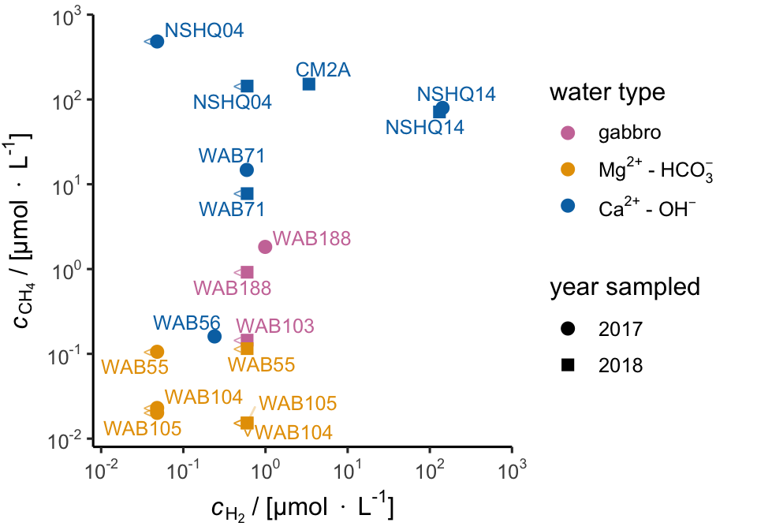

```r
# add factors for order of display in legend
data_CH4_H2$water_type <- factor(data_CH4_H2$water_type, levels = c("gabbro", "Mg_HCO3", "Ca_OH"))

# create plot
H2_CH4_plot <- data_CH4_H2 %>% ggplot() +

  # plot data
  aes(
    x = H2_uM_LQ_sub_for_NA,
    y = CH4_uM_LQ_sub_for_NA,
    label = sampling_site,
    color = water_type,
    shape = as.character(year_sampled)
    ) +
    geom_point(size = 2.5) +

  # plot arrows denoting "below limit of quantitation"
  geom_text(data = data_CH4_H2 %>% filter(is.na(CH4_uM)), aes(
    x = H2_uM_LQ_sub_for_NA,
    y = CH4_uM_LQ_sub_for_NA,
    label = "^",
    color = water_type
    ), alpha = 0.7, angle = 180, nudge_y = -0.08, nudge_x = 0.01, show.legend = FALSE, size = 3) +

  geom_text(data = data_CH4_H2 %>% filter(is.na(H2_uM)), aes(
    x = H2_uM_LQ_sub_for_NA,
    y = CH4_uM_LQ_sub_for_NA,
    label = "^",
    color = water_type
    ), alpha = 0.7, angle = 90, nudge_x = -0.08, nudge_y = 0.0015, show.legend = FALSE, size = 3) +

  # symbol styling
  scale_color_manual(name = "water type", values=cbPalette_water_types, guide = guide_legend(ncol= 1, order = 1), labels = unname(latex2exp::TeX(c("gabbro", "Mg$^{2+}$ - HCO$_{3}^{-}$", "Ca$^{2+}$ - OH$^{-}$"))))+
  scale_shape_manual(name = "year sampled", values = c(19, 15), guide = guide_legend(ncol = 1, order = 2)) +
  # text labels
  geom_text_repel(size=3.34, force = 1.1, segment.alpha = .3, show.legend = FALSE) +

  # axis styling
  scale_y_continuous(trans = 'log10',
      breaks = trans_breaks('log10', function(x) 10 ^ x, n=6),
      labels = trans_format('log10', math_format(10^.x)),
      limits = c(8e-3, 1e3), expand = c(0, 0),
      name = latex2exp::TeX("\\textit{c}_{CH_4} / $\\lbrack$µmol $\\cdot$ L$^{-1}$$\\rbrack$")) +
  scale_x_continuous(trans = 'log10',
      breaks = trans_breaks('log10', function(x) 10 ^ x, n=6),
      labels = trans_format('log10', math_format(10^.x)),
      limits = c(8e-3, 1e3), expand = c(0, 0),
      name = latex2exp::TeX("\\textit{c}_{H_2} / $\\lbrack$µmol $\\cdot$ L$^{-1}$$\\rbrack$"))+

  # design
  theme_classic(base_size = 12)+
  theme(
    # legend.position = "bottom",
    # legend.direction = "vertical",
    # legend.box = "horizontal",
    legend.text.align = 0,
    plot.margin = margin(7, 10, 1, 1, "pt")
    )

# print plot
H2_CH4_plot
```

# 5 $\delta\text{D}_{\text{CH}_4}$ vs. $\delta^{13}\text{C}_{\text{CH}_4}$ (“CD”) plot

## 5.1 Prepare data

Prepare Oman well data

```r
# make data frame of CH4 d13C data
data_C_gathered <- data_CD %>% select(sampling_site, year_sampled, water_type, CH4_d13C_permil_VPDB_CUB, CH4_d13C_permil_VPDB_MIT, CH4_d13C_permil_VPDB_UCLA, CH4_d13C_permil_VPDB_LBNL, site, depth_fluid_intake_mbct) %>% gather(key = "parameter", value = "CH4_d13C_permil_VPDB", -sampling_site, -water_type, -year_sampled, -site, -depth_fluid_intake_mbct)

# make a column for analytical laboratory
data_C_gathered <- data_C_gathered %>% mutate(lab = case_when(
str_detect(parameter, "LBNL") == TRUE ~ "LBNL",
str_detect(parameter, "CUB") == TRUE ~ "CUB",
str_detect(parameter, "MIT") == TRUE ~ "MIT",
str_detect(parameter, "UCLA") == TRUE ~ "UCLA"
))  %>%  select(-parameter)

# repeat the above for dD
data_D_gathered <- data_CD %>% select(sampling_site, water_type, year_sampled, CH4_dD_permil_VSMOW_CUB, CH4_dD_permil_VSMOW_MIT, CH4_dD_permil_VSMOW_UCLA, CH4_dD_permil_VSMOW_LBNL) %>% gather(key = "parameter", value = "CH4_dD_permil_VSMOW", -sampling_site, -water_type, -year_sampled)

data_D_gathered <- data_D_gathered %>% mutate(lab = case_when(
str_detect(parameter, "LBNL") == TRUE ~ "LBNL",
str_detect(parameter, "CUB") == TRUE ~ "CUB",
str_detect(parameter, "MIT") == TRUE ~ "MIT",
str_detect(parameter, "UCLA") == TRUE ~ "UCLA"
))  %>%  select(-parameter)

# combine 13C and D data
data_CD_gathered <- full_join(data_C_gathered, data_D_gathered)
```

## 5.2 Plot

### 5.2.1 Plot data

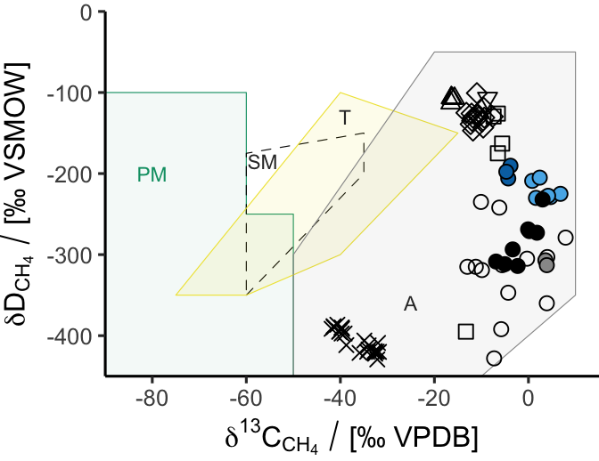

```r
# Set coordinates of fields of origins (Milkov and Etiope 2018)

primary_microbial <- data.frame(
  x = c(-90, -50, -50, -60, -60, -90),
  y = c(-450,-450,-250, -250, -100, -100)
)

secondary_microbial <- data.frame(
  x = c(-60,-35,-35, -60),
  y = c(-350, -200, -150, -175)
)

thermogenic <- data.frame(
  x = c(-75, -60, -40, -15, -40),
  y = c(-350, -350, -300, -150, -100)
)

abiotic <- data.frame(
  x = c(-50, -10, 10, 10, -20, -50),
  y = c(-450,-450, -350, -50, -50, -300)
)

# create plot
CD_plot <-
  ggplot() +

  # add origin fields
  geom_polygon(data = primary_microbial, aes(x=x, y=y), fill = microbial_color, alpha = microbial_opacity, color = microbial_color, size = .2) +
  geom_polygon(data = secondary_microbial, aes(x=x, y=y), alpha = 0.1, fill = NA, color = "black", size = .2, linetype = "dashed") +
  geom_polygon(data = thermogenic, aes(x=x, y=y), alpha = thermo_opacity, fill = thermogenic_color, color = thermogenic_color, size = .2) +
  geom_polygon(data = abiotic, aes(x=x, y=y), alpha = abiotic_opacity, fill = abiotic_color, color = abiotic_color, size = .2) +

  # plot literature data
  geom_point(data = data_literature %>% filter(sample_type != "laboratory synthesis" ),  aes(
    x = CH4_d13C_permil_VPDB,
    y = CH4_dD_permil_VSMOW,
    shape = site
    ), alpha = 1, size = 2.5) +

  # plot Oman well data
  geom_point(data = data_CD_gathered,  aes(
    x = CH4_d13C_permil_VPDB,
    y = CH4_dD_permil_VSMOW,
    shape = site,
    fill = sampling_site
    ), alpha = 1, size = 2.5) +

  # axis styling
  scale_y_continuous(name = latex2exp::TeX("$\\delta D_{CH_4}\\,/\\,\\[\U2030  \\, VSMOW \\]$"), limits = c(-450, 0), expand = c(0,0)) +
  scale_x_continuous(name = latex2exp::TeX("$\\delta ^{13}C_{CH_4}\\,/\\,\\[\U2030  \\, VPDB \\]$"), limits = c(-90, 15), expand = c(0,0)) +

  # symbol styling
  scale_fill_manual(values = fill_4_wells_named, name="water type", guide = guide_legend(order = 2)) +
  scale_shape_manual(values = shapes_all_sites_named, guide = guide_legend(ncol = 2, order = 1)) +

  # annotations
  annotate("text", y = -200, x= -80, size = 3, label = "PM", color = microbial_color) +
  annotate("text", y = -185, x= -56.5, size = 3, label = "SM", color = "grey20") +
  annotate("text", y = -130, x= -39, size = 3, label = "T", color = "grey20") +
  annotate("text", y = -360, x= -25, size = 3, label = "A", color = "grey20") +

  # design
  theme_classic(base_size = 12)+
  theme(
    plot.margin = margin(5, 0, 0, 0, "pt"),
    legend.position = "none"
    )

# print
CD_plot
```

### 5.2.2 Extract fill legend

Make a dummy plot for extracting plot legend

```r
# add factors to data to organize legend entries labels
data_CD_gathered_factored <- data_CD_gathered$sampling_site <- factor(data_CD_gathered$sampling_site, levels = c("NSHQ04", "WAB71", "CM2A", "NSHQ14"))

# create plot
CD_leg_fill_plot <-
  ggplot() +

  # origin fields
  geom_polygon(data = primary_microbial, aes(x=x, y=y), fill = microbial_color, alpha = microbial_opacity, color = microbial_color, size = .2)+
  geom_polygon(data = secondary_microbial, aes(x=x, y=y), alpha = 0.1, fill = NA, color = "black", size = .2, linetype = "dashed")+
  geom_polygon(data = thermogenic, aes(x=x, y=y), alpha = thermo_opacity, fill = thermogenic_color, color = thermogenic_color, size = .2)+
  geom_polygon(data = abiotic, aes(x=x, y=y), alpha = abiotic_opacity, fill = abiotic_color, color = abiotic_color, size = .2)+

  # plot Oman well data
  geom_point(data = data_CD_gathered,  aes(
    x = CH4_d13C_permil_VPDB,
    y = CH4_dD_permil_VSMOW,
    shape = site,
    fill = sampling_site
    ), alpha = 1, size = 2.5) +

  # axis styling
  scale_y_continuous(name = latex2exp::TeX("$\\delta D_{CH_4}$$\\,$/$\\,$\\lbrack$$‰ VSMOW$\\rbrack$"), limits = c(-450, 0), expand = c(0,0), sec.axis = dup_axis())+
  scale_x_continuous(name = latex2exp::TeX("$\\delta ^{13}C_{CH_4}$$\\,$/$\\,$‰ VPDB"), limits = c(-90, 15), expand = c(0,0), sec.axis = dup_axis())+

  # symbol styling
  scale_fill_manual(values = fill_4_wells_named, name="well (this study)", guide = guide_legend(override.aes = list(shape = 21))) +
  scale_shape_manual(values = shapes_all_sites_named, guide = FALSE)+

  # annotations
  annotate("text", y = -200, x= -80, size = 3, label = "PM", color = microbial_color) +
  annotate("text", y = -185, x= -56.5, size = 3, label = "SM", color = "grey20") +
  annotate("text", y = -130, x= -39, size = 3, label = "T", color = "grey20") +
  annotate("text", y = -360, x= -25, size = 3, label = "A/CLM", color = "grey20") +

  # design
  theme_classic(base_size = 12)+
  theme(panel.grid = element_blank(),
    plot.margin = margin(0, 2, 1, 1, "pt"),
    legend.position = "right",
    axis.title.y.right = element_blank(),
    axis.text.y.right = element_blank(),
    axis.text.x.bottom = element_blank(),
    axis.title.x = element_blank()
    )
```

Extract fill legend

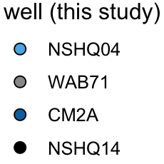

```r
# extract shape legend
leg_fill <- get_legend(CD_leg_fill_plot)

# create plot
leg_fill_plot <- plot_grid(leg_fill)

# print plot
leg_fill_plot
```

# 6 $c_{\Sigma\text{CO}_2}$ vs. $\delta^{13}\text{C}_{\text{CH}_4}$

```r
# make data frame of CH4 d13C and dD data for all wells
data_CD_DIC  <- data %>% select(sampling_site, year_sampled, depth_fluid_intake_mbct, water_type, CH4_d13C_permil_VPDB_LBNL, CH4_dD_permil_VSMOW_LBNL,
CH4_d13C_permil_VPDB_CUB, CH4_dD_permil_VSMOW_CUB, CH4_d13C_permil_VPDB_MIT, CH4_dD_permil_VSMOW_MIT, CH4_d13C_permil_VPDB_UCLA, CH4_dD_permil_VSMOW_UCLA, site, DIC_uM, DIC_was_measured, DIC_unc_uM, DIC_LQ_uM)

# compute means between analyses in multiple labs
data_CD_DIC  <- data_CD_DIC %>%
    rowwise() %>%
    mutate(CH4_d13C_permil_VPDB_interlab_mean  = mean(c(CH4_d13C_permil_VPDB_LBNL, CH4_d13C_permil_VPDB_CUB, CH4_d13C_permil_VPDB_MIT, CH4_d13C_permil_VPDB_UCLA), na.rm = TRUE))

data_CD_DIC <- data_CD_DIC %>%
    rowwise() %>%
    mutate(CH4_dD_permil_VSMOW_interlab_mean  = mean(c(CH4_dD_permil_VSMOW_LBNL, CH4_dD_permil_VSMOW_CUB, CH4_dD_permil_VSMOW_MIT, CH4_dD_permil_VSMOW_UCLA), na.rm = TRUE))

# remove samples without C isotope data
data_CD_DIC <- data_CD_DIC %>% filter(!is.nan(CH4_d13C_permil_VPDB_interlab_mean))

data_CD_DIC <- data_CD_DIC %>% mutate(DIC_uM_LQ_sub = if_else(is.na(DIC_uM), 8, DIC_uM))

data_CD_DIC <- data_CD_DIC %>% mutate(DIC_was_quantitated = if_else(is.na(DIC_uM), FALSE, TRUE))

# print
data_CD_DIC %>% select(sampling_site, year_sampled, CH4_d13C_permil_VPDB_interlab_mean, DIC_was_measured, DIC_uM, DIC_LQ_uM, DIC_uM_LQ_sub, DIC_was_quantitated)
```

| sampling_site | year_sampled | CH4_d13C_permil_VPDB_interlab_mean | DIC_was_measured | DIC_uM | DIC_LQ_uM | DIC_uM_LQ_sub | DIC_was_quantitated |
| --- | --- | --- | --- | --- | --- | --- | --- |
| CM2A | 2018 | -4.280000 | TRUE | NA | 12.0 | 8 | FALSE |
| NSHQ04 | 2018 | 4.438500 | TRUE | 18 | 12.0 | 18 | TRUE |
| NSHQ14 | 2018 | -3.557333 | TRUE | NA | 12.0 | 8 | FALSE |
| WAB188 | 2018 | -86.700000 | TRUE | 3480 | 12.0 | 3480 | TRUE |
| WAB71 | 2018 | 3.600000 | TRUE | NA | 12.0 | 8 | FALSE |
| NSHQ04 | 2017 | 5.195000 | TRUE | 37 | 20.0 | 37 | TRUE |
| NSHQ14 | 2017 | 0.060000 | TRUE | 130 | 20.0 | 130 | TRUE |
| WAB188 | 2017 | -60.800000 | TRUE | 3000 | 20.0 | 3000 | TRUE |
| WAB71 | 2017 | 3.900000 | TRUE | 120 | 20.0 | 120 | TRUE |
| NSHQ14 | 2016 | -2.545000 | FALSE | NA | NA | 8 | FALSE |

[output cut: 8 more lines]

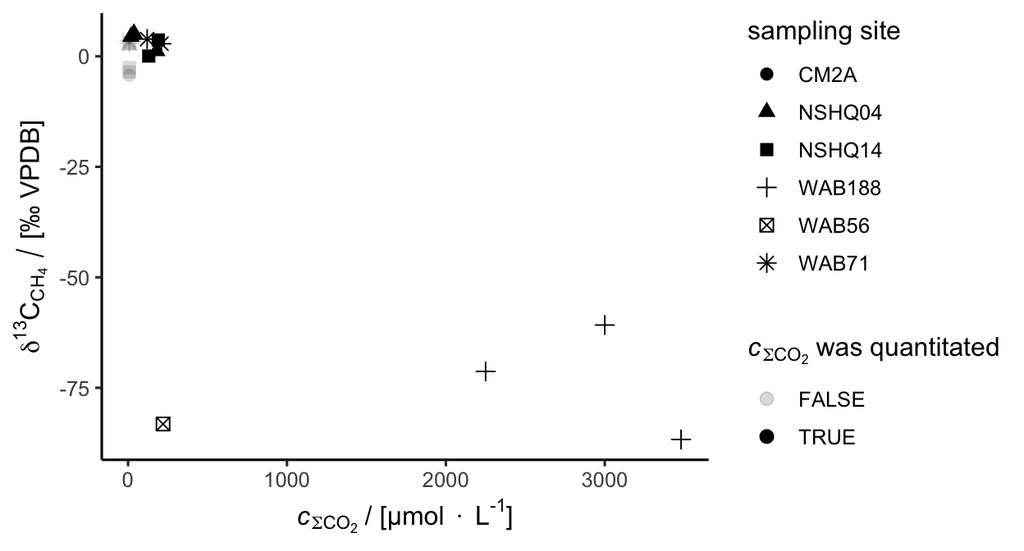

```r
# create plot
DIC_d13C_CH4_plot <- data_CD_DIC %>% filter(!is.na(DIC_uM_LQ_sub)) %>% ggplot() +

  # plot data
  aes(
    x = DIC_uM_LQ_sub,
    y = CH4_d13C_permil_VPDB_interlab_mean,
    shape = sampling_site,
    color = DIC_was_quantitated
    ) +
  # plot styling
  geom_point(size = 2.5) +
  scale_color_manual(name = latex2exp::TeX("$\\textit{c}_{\\Sigma CO_2}$ was quantitated"),values = color_TF) +
  scale_shape_discrete(name = "sampling site") +
  scale_y_continuous(name = latex2exp::TeX("$\\delta ^{13}C_{CH_4}$$\\,$/$\\,$$\\lbrack$‰ VPDB$\\rbrack$")) +
  scale_x_continuous(name = latex2exp::TeX("$\\textit{c}_{\\Sigma CO_2}$ / $\\lbrack$µmol $\\cdot$ L$^{-1}$$\\rbrack$")) +
  theme_classic(base_size = 12)

# print plot
DIC_d13C_CH4_plot
```

# 7 C$_1$ / (C$_2$ + C$_3$) vs. $\delta^{13}\text{C}_{\text{CH}_4}$ (“Bernard”) Plot

## 7.1 Prepare data

Prepare Oman well data

```r
# select samples with quantifiable C2H6
data_C1_C2_C3 <- data %>% filter(!is.na(C2H6_uM)) %>%  select(sampling_site, year_sampled, depth_fluid_intake_mbct, water_type, CH4_uM, CH4_was_measured, CH4_LQ_uM, CH4_unc_uM, C2H6_uM, C2H6_was_measured, C2H6_LQ_uM, C2H6_unc_uM, C3H8_uM, C3H8_was_measured, C3H8_LQ_uM, C3H8_unc_uM,
CH4_d13C_permil_VPDB_CUB, CH4_d13C_unc_permil_CUB) # select relevant data for CH4, C2H6, C3H8

data_C1_C2_C3  <- data_C1_C2_C3  %>%  filter(CH4_uM > 0.5) # filter for samples for with greater than 0.5 µmol/L CH4

# calculate C1/(C2+C3)
data_C1_C2_C3 <- data_C1_C2_C3 %>% mutate(C1_over_C2_plus_C3 = CH4_uM / (C2H6_uM + if_else(!is.na(C3H8_uM), C3H8_uM, 0)))

# summarize wells with multiple replicates in a given year (NSHQ14 2017)
data_C1_C2_C3 <- data_C1_C2_C3 %>% group_by(sampling_site, year_sampled) %>% summarise(water_type = first(water_type), C1_over_C2_plus_C3 = mean(C1_over_C2_plus_C3),  CH4_d13C_permil_VPDB_CUB = mean(CH4_d13C_permil_VPDB_CUB, na.rm = TRUE), CH4_uM = mean(CH4_uM), C2H6_uM = mean(C2H6_uM), C3H8_uM = mean(C3H8_uM)) %>% ungroup()
data_C1_C2_C3 <- data_C1_C2_C3 %>% mutate(site = "Oman/UAE")

# print
data_C1_C2_C3
```

| sampling_site | year_sampled | water_type | C1_over_C2_plus_C3 | CH4_d13C_permil_VPDB_CUB | CH4_uM | C2H6_uM | C3H8_uM | site |
| --- | --- | --- | --- | --- | --- | --- | --- | --- |
| CM2A | 2018 | Ca_OH | 3541.4951 | -4.3 | 151.84580 | 0.04112293 | 0.001753253 | Oman/UAE |
| NSHQ04 | 2018 | Ca_OH | 5380.8597 | 4.7 | 143.75255 | 0.02450000 | 0.002215536 | Oman/UAE |
| NSHQ14 | 2017 | Ca_OH | 1239.2713 | 0.2 | 79.52095 | 0.05815882 | 0.006991448 | Oman/UAE |
| NSHQ14 | 2018 | Ca_OH | 881.1067 | -2.3 | 71.23263 | 0.07320627 | 0.007638227 | Oman/UAE |

Get literature data

```r
# select samples with quantifiable C2H6
data_C1_C2_C3_lit <- data_literature %>% filter(!is.na(C2H6_conc)) %>%  select(site, sample_type, CH4_conc, C2H6_conc, C3H8_conc,
CH4_d13C_permil_VPDB) # select relevant data for CH4, C2H6, C3H8

# calculate C1/(C2+C3)
data_C1_C2_C3_lit <- data_C1_C2_C3_lit %>% mutate(C1_over_C2_plus_C3 = CH4_conc / (C2H6_conc + if_else(!is.na(C3H8_conc), C3H8_conc, 0)))

# print
data_C1_C2_C3_lit
```

| site | sample_type | CH4_conc | C2H6_conc | C3H8_conc | CH4_d13C_permil_VPDB | C1_over_C2_plus_C3 |
| --- | --- | --- | --- | --- | --- | --- |
| Philippines | vent/well fluid | 130000.0 | 4.000e+02 | NA | -7.10 | 325.000000 |
| Philippines | vent/well fluid | 553000.0 | 1.500e+03 | NA | -7.42 | 368.666667 |
| Philippines | vent/well fluid | 548000.0 | 1.200e+03 | NA | -6.52 | 456.666667 |
| Oman/UAE | vent/well fluid | 15000.0 | 6.960e+01 | 1.50e+01 | NA | 177.304965 |
| Oman/UAE | vent/well fluid | 16000.0 | 7.030e+01 | 1.47e+01 | NA | 188.235294 |
| Oman/UAE | vent/well fluid | 25000.0 | 7.070e+01 | 1.49e+01 | NA | 292.056075 |
| Oman/UAE | vent/well fluid | 15000.0 | 9.900e+00 | 8.20e+00 | NA | 828.729282 |
| Oman/UAE | vent/well fluid | 15000.0 | 9.500e+00 | 7.80e+00 | NA | 867.052023 |
| Oman/UAE | vent/well fluid | 56000.0 | 1.010e+01 | NA | NA | 5544.554455 |
| Oman/UAE | vent/well fluid | 55000.0 | 1.120e+01 | NA | NA | 4910.714286 |

[output cut: 58 more lines]

## 7.2 Plot

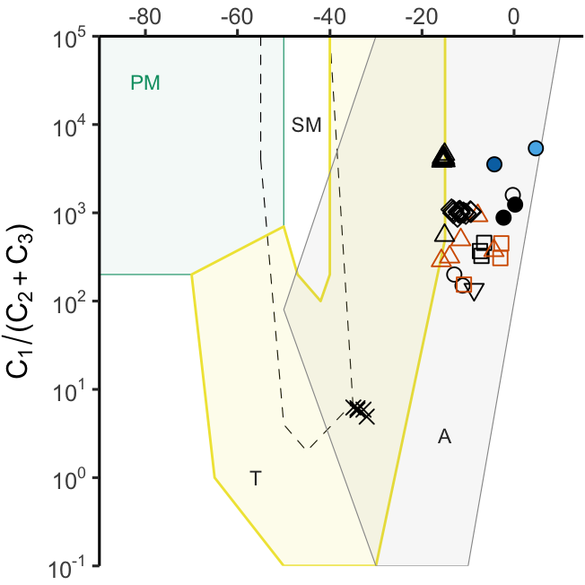

```r
# Set coordinates of fields of origins (Milkov and Etiope 2018)
primary_microbial_bernard <- data.frame(
  x = c(-90,-70,-50, -50, -90),
  y = c(2e2,2e2,7e2, 1e5, 1e5)
)

secondary_microbial_bernard <- data.frame(
  x = c(-55, -50, -45, -35, -40, -55),
  y = c(4e3, 4e0, 2e0, 7e0, 1e5, 1e5)
)

thermogenic_bernard <- data.frame(
  x = c(-50, -65, -70, -50, -47, -42, -40, -40, -15, -15, -30, -50),
  y = c(1e-1, 1e0, 2e2, 7e2, 2e2, 1e2, 2e2, 1e5, 1e5, 5e2, 1e-1, 1e-1)
)

abiotic_bernard <- data.frame(
  x = c(-50, -30, -10, 10, -30),
  y = c(8e1, 1e-1, 1e-1, 1e5, 1e5)
)

# create plot
C1_C2_C3_plot <-
  ggplot() +

  # add origin fields
  geom_polygon(data = primary_microbial_bernard, aes(x=x, y=y), fill = microbial_color, alpha = microbial_opacity, color = microbial_color, size = 0.2) +
  geom_polygon(data = secondary_microbial_bernard, aes(x=x, y=y), fill = NA, color = "black", size = 0.2, linetype = "dashed") +
  geom_polygon(data = thermogenic_bernard, aes(x=x, y=y), alpha = thermo_opacity, fill = thermogenic_color, color = thermogenic_color, size = 0.5) +
  geom_polygon(data = abiotic_bernard, aes(x=x, y=y), alpha= abiotic_opacity, fill = abiotic_color, color = abiotic_color, size = .2) +

  # add text annotations
  annotate("text", y = 3e4, x = -80, size = 3, label = "PM", color = microbial_color) +
  annotate("text", y = 1e4, x = -45, size = 3, label = "SM", color = "grey20") +
  annotate("text", y = 1e0, x = -56, size = 3, label = "T", color = "grey20") +
  annotate("text", y = 3e0, x = -15, size = 3, label = "A", color = "grey20") +

  # plot literature data
  geom_point(data = data_C1_C2_C3_lit,
    aes(
    x = CH4_d13C_permil_VPDB,
    y = C1_over_C2_plus_C3,
    shape = site,
    color = sample_type,
    ), alpha = 1, size = 2.5) +

  # plot Oman well data
  geom_point(data = data_C1_C2_C3,
    aes(
    x = CH4_d13C_permil_VPDB_CUB ,
    y = C1_over_C2_plus_C3,
    shape = site,
    fill = sampling_site
    ), alpha = 1, size = 2.5) +

  # axis styling
  scale_y_continuous(trans = 'log10',
    breaks = trans_breaks('log10', function(x) 10 ^ x, n=5),
    labels = trans_format('log10', math_format(10^.x)),
    limits = c(.1, 1e5), expand = c(0,0),
    name = latex2exp::TeX("$C_1$/($C_{2}$+$C_{3}$)"))+
    scale_x_continuous(name = latex2exp::TeX("$\\delta ^{13}C_{CH_4}$$\\,$/$\\,$$\\lbrack$‰ VPDB$\\rbrack$"), limits = c(-90, 15), expand = c(0,0), sec.axis = dup_axis()) +

  # symbol styling
  scale_shape_manual(values = shapes_all_sites_named) +
  scale_color_manual(values = color_rock_crush_named) +
  scale_fill_manual(values = fill_4_wells_named, name = "water type", guide = guide_legend(order = 2)) +

  # design
  theme_classic(base_size = 12)+
  theme(
    axis.title.x = element_blank(),
    axis.text.x.bottom = element_blank(),
    axis.ticks.x.bottom = element_blank(),
    axis.line.x.bottom = element_blank(),
    plot.margin = margin(1, 1, 5, 1, "pt"),
    legend.position = "none"
    )

# print plot
C1_C2_C3_plot
```

# 8 Doubly-substituted (“clumped”) isotopologues

## 8.1 $\Delta^{13}\text{CH}_3\text{D}$ and $\epsilon_{\text{CH}_4/\text{H}_2\text{O}}$

### 8.1.1 Prepare data

Get CH$_4$ clumped isotopologue data

```r
# make data frame of CH4 clumped isotopologue data
data_clumps <- data %>% filter(!is.na(cap13CH3D_permil_UCLA) | !is.na(cap13CH3D_permil_MIT)) %>% select(site, sampling_site, year_sampled, cap12CH2D2_permil_UCLA, cap12CH2D2_unc_permil_UCLA, cap13CH3D_permil_UCLA, cap13CH3D_unc_permil_UCLA,  CH4_dD_permil_VSMOW_UCLA, cap13CH3D_permil_MIT, cap13CH3D_unc_permil_MIT, CH4_dD_permil_VSMOW_MIT)

# print
data_clumps
```

| site | sampling_site | year_sampled | cap12CH2D2_permil_UCLA | cap12CH2D2_unc_permil_UCLA | cap13CH3D_permil_UCLA | cap13CH3D_unc_permil_UCLA | CH4_dD_permil_VSMOW_UCLA | cap13CH3D_permil_MIT | cap13CH3D_unc_permil_MIT | CH4_dD_permil_VSMOW_MIT |
| --- | --- | --- | --- | --- | --- | --- | --- | --- | --- | --- |
| Oman/UAE | CM2A | 2018 | -1.267 | 0.886 | 2.638 | 0.284 | -197.730 | 2.87 | 0.57 | -190.32 |
| Oman/UAE | NSHQ04 | 2018 | -24.502 | 0.944 | 0.229 | 0.288 | -227.396 | NA | NA | NA |
| Oman/UAE | NSHQ14 | 2018 | -0.204 | 1.358 | 2.074 | 0.298 | -293.580 | 0.77 | 0.44 | -311.73 |
| Oman/UAE | NSHQ04 | 2017 | NA | NA | NA | NA | NA | 0.12 | 0.17 | -229.67 |
| Oman/UAE | NSHQ14 | 2017 | NA | NA | NA | NA | NA | 0.69 | 0.23 | -268.82 |
| Oman/UAE | NSHQ14 | 2016 | NA | NA | NA | NA | NA | 0.55 | 0.17 | -308.52 |
| Oman/UAE | NSHQ04 | 2015 | NA | NA | NA | NA | NA | 0.72 | 0.29 | -230.00 |

Add $\delta\text{D}_{\text{H}_{2}\text{O}}$ data

```r
# add water stable isotope data to CH4 clumped isotopologue data
data_clumps <- data_clumps %>% left_join(data_water_isotopes_summ_well %>% select(sampling_site, H2O_dD_permil_VSMOW_mean_well))
# convert delta value from permil to raw delta value
data_clumps <- data_clumps %>% mutate(H2O_dD_VSMOW_mean_well = H2O_dD_permil_VSMOW_mean_well / 1000)
```

Calculate $\epsilon_{\text{methane/water}}$.

```r
# convert delta value from permil to raw delta value
data_clumps <- data_clumps %>% mutate(CH4_dD_VSMOW_UCLA = CH4_dD_permil_VSMOW_UCLA / 1000)
data_clumps <- data_clumps %>% mutate(CH4_dD_VSMOW_MIT = CH4_dD_permil_VSMOW_MIT / 1000)

# calculate alpha
data_clumps <- data_clumps %>% mutate(alpha_CH4_H2O_UCLA = (CH4_dD_VSMOW_UCLA + 1)/(H2O_dD_VSMOW_mean_well + 1))
data_clumps <- data_clumps %>% mutate(alpha_CH4_H2O_MIT = (CH4_dD_VSMOW_MIT + 1)/(H2O_dD_VSMOW_mean_well + 1))

# calculate epsilon
data_clumps <- data_clumps %>% mutate(eps_CH4_H2O_UCLA = alpha_CH4_H2O_UCLA - 1)
data_clumps <- data_clumps %>% mutate(eps_CH4_H2O_MIT = alpha_CH4_H2O_MIT - 1)

# convert epsilon from raw value to permil
data_clumps <- data_clumps %>% mutate(eps_CH4_H2O_permil_UCLA = eps_CH4_H2O_UCLA * 1000)
data_clumps <- data_clumps %>% mutate(eps_CH4_H2O_permil_MIT = eps_CH4_H2O_MIT * 1000)

# print
data_clumps
```

| site | sampling_site | year_sampled | cap12CH2D2_permil_UCLA | cap12CH2D2_unc_permil_UCLA | cap13CH3D_permil_UCLA | cap13CH3D_unc_permil_UCLA | CH4_dD_permil_VSMOW_UCLA | cap13CH3D_permil_MIT | cap13CH3D_unc_permil_MIT | CH4_dD_permil_VSMOW_MIT | H2O_dD_permil_VSMOW_mean_well | H2O_dD_VSMOW_mean_well | CH4_dD_VSMOW_UCLA | CH4_dD_VSMOW_MIT | alpha_CH4_H2O_UCLA | alpha_CH4_H2O_MIT | eps_CH4_H2O_UCLA | eps_CH4_H2O_MIT | eps_CH4_H2O_permil_UCLA | eps_CH4_H2O_permil_MIT |
| --- | --- | --- | --- | --- | --- | --- | --- | --- | --- | --- | --- | --- | --- | --- | --- | --- | --- | --- | --- | --- |
| Oman/UAE | CM2A | 2018 | -1.267 | 0.886 | 2.638 | 0.284 | -197.730 | 2.87 | 0.57 | -190.32 | 1.7000000 | 0.0017000000 | -0.197730 | -0.19032 | 0.8009085 | 0.8083059 | -0.1990915 | -0.1916941 | -199.0915 | -191.6941 |
| Oman/UAE | NSHQ04 | 2018 | -24.502 | 0.944 | 0.229 | 0.288 | -227.396 | NA | NA | NA | -10.6350000 | -0.0106350000 | -0.227396 | NA | 0.7809090 | NA | -0.2190910 | NA | -219.0910 | NA |
| Oman/UAE | NSHQ14 | 2018 | -0.204 | 1.358 | 2.074 | 0.298 | -293.580 | 0.77 | 0.44 | -311.73 | 0.6611111 | 0.0006611111 | -0.293580 | -0.31173 | 0.7059533 | 0.6878153 | -0.2940467 | -0.3121847 | -294.0467 | -312.1847 |
| Oman/UAE | NSHQ04 | 2017 | NA | NA | NA | NA | NA | 0.12 | 0.17 | -229.67 | -10.6350000 | -0.0106350000 | NA | -0.22967 | NA | 0.7786105 | NA | -0.2213895 | NA | -221.3895 |
| Oman/UAE | NSHQ14 | 2017 | NA | NA | NA | NA | NA | 0.69 | 0.23 | -268.82 | 0.6611111 | 0.0006611111 | NA | -0.26882 | NA | 0.7306969 | NA | -0.2693031 | NA | -269.3031 |
| Oman/UAE | NSHQ14 | 2016 | NA | NA | NA | NA | NA | 0.55 | 0.17 | -308.52 | 0.6611111 | 0.0006611111 | NA | -0.30852 | NA | 0.6910232 | NA | -0.3089768 | NA | -308.9768 |
| Oman/UAE | NSHQ04 | 2015 | NA | NA | NA | NA | NA | 0.72 | 0.29 | -230.00 | -10.6350000 | -0.0106350000 | NA | -0.23000 | NA | 0.7782770 | NA | -0.2217230 | NA | -221.7230 |

Gather $\Delta^{13}\text{CH}_3\text{D}$ data from different labs into one column.

```r
# gather ∆13CH3D data from different labs into one column
data_clumps_gathered_cap13CH3D <- data_clumps %>% select(sampling_site, year_sampled, cap13CH3D_permil_MIT, cap13CH3D_permil_UCLA) %>% gather(-sampling_site, -year_sampled, value = cap13CH3D_permil, key = lab)

# ensure ∆13CH3D value is of numeric class
data_clumps_gathered_cap13CH3D <- data_clumps_gathered_cap13CH3D %>%  mutate(cap13CH3D_permil = as.numeric(cap13CH3D_permil))

# filter for rows with with ∆13CH3D data
data_clumps_gathered_cap13CH3D <- data_clumps_gathered_cap13CH3D %>% filter(!is.na(cap13CH3D_permil))

# print
data_clumps_gathered_cap13CH3D
```

| sampling_site | year_sampled | lab | cap13CH3D_permil |
| --- | --- | --- | --- |
| CM2A | 2018 | cap13CH3D_permil_MIT | 2.870 |
| NSHQ14 | 2018 | cap13CH3D_permil_MIT | 0.770 |
| NSHQ04 | 2017 | cap13CH3D_permil_MIT | 0.120 |
| NSHQ14 | 2017 | cap13CH3D_permil_MIT | 0.690 |
| NSHQ14 | 2016 | cap13CH3D_permil_MIT | 0.550 |
| NSHQ04 | 2015 | cap13CH3D_permil_MIT | 0.720 |
| CM2A | 2018 | cap13CH3D_permil_UCLA | 2.638 |
| NSHQ04 | 2018 | cap13CH3D_permil_UCLA | 0.229 |
| NSHQ14 | 2018 | cap13CH3D_permil_UCLA | 2.074 |

Summarize $\Delta^{13}\text{CH}_3\text{D}$ by well and year

```r
# summarize
data_clumps_gathered_summ_well_year_cap13CH3D <- data_clumps_gathered_cap13CH3D %>% select(sampling_site, year_sampled, cap13CH3D_permil) %>%  group_by(sampling_site, year_sampled) %>% summarise(n = n(), cap13CH3D_permil_mean = mean(cap13CH3D_permil), cap13CH3D_permil_sd = sd(cap13CH3D_permil))
# print
data_clumps_gathered_summ_well_year_cap13CH3D
```

| sampling_site | year_sampled | n | cap13CH3D_permil_mean | cap13CH3D_permil_sd |
| --- | --- | --- | --- | --- |
| CM2A | 2018 | 2 | 2.754 | 0.1640488 |
| NSHQ04 | 2015 | 1 | 0.720 | NA |
| NSHQ04 | 2017 | 1 | 0.120 | NA |
| NSHQ04 | 2018 | 1 | 0.229 | NA |
| NSHQ14 | 2016 | 1 | 0.550 | NA |
| NSHQ14 | 2017 | 1 | 0.690 | NA |
| NSHQ14 | 2018 | 2 | 1.422 | 0.9220672 |

Summarize interannual mean $\Delta^{13}\text{CH}_3\text{D}$ for each well

```r
# summarize across years
data_clumps_gathered_summ_well_interannual_cap13CH3D <- data_clumps_gathered_summ_well_year_cap13CH3D %>% group_by(sampling_site) %>% summarise(n=n(), cap13CH3D_permil_mean_mean = mean(cap13CH3D_permil_mean), cap13CH3D_permil_mean_sd = sd(cap13CH3D_permil_mean))
# print
data_clumps_gathered_summ_well_interannual_cap13CH3D
```

| sampling_site | n | cap13CH3D_permil_mean_mean | cap13CH3D_permil_mean_sd |
| --- | --- | --- | --- |
| CM2A | 1 | 2.7540000 | NA |
| NSHQ04 | 3 | 0.3563333 | 0.3196253 |
| NSHQ14 | 3 | 0.8873333 | 0.4682962 |

### 8.1.2 Plot

Generate equilibrium curves

```r
# make temperature axis.
temp_axis_wang <- c(0, 50, 100, 200, 400) # create vector of temperature axis from Wang et al. (2015)
temp_axis_wang_DF <- as.data.frame(temp_axis_wang) # convert above vector to data frame
temp_axis_wang_DF <- temp_axis_wang_DF %>% rename(temp_C = temp_axis_wang) # rename column
temp_axis_wang_DF <- temp_axis_wang_DF %>% mutate(cap13CH3D_temp = 1000*log(1+0.0355502*(1/(temp_C+273.15))-433.038*(1/(temp_C+273.15))^2+1270210*(1/(temp_C+273.15))^3-594804000*(1/(temp_C+273.15))^4+119663000000*(1/(temp_C+273.15))^5-9072300000000*(1/(temp_C+273.15))^6)) # calculate ∆13CH3D as function of temperature using equation from Young et al. (2017)

# solve CH4-H2O equilibrium curve (Horibe and Craig, 1995)
eq_curve_wang <- seq(0, 370, by = 5) # create sequence from 0 to 370 in increments of 5 to serve as equilbrium curve
eq_curve_wang_DF <- as.data.frame(eq_curve_wang ) # convert above vector into data frame
eq_curve_wang_DF <- eq_curve_wang_DF %>% rename(temp_C = eq_curve_wang) # rename column
eq_curve_wang_DF <- eq_curve_wang_DF %>% mutate(temp_K = temp_C + 273.15) # add column for temperature in Kelvin
eq_curve_wang_DF <- eq_curve_wang_DF %>% mutate(cap13CH3D_temp = 1000*log(1+0.0355502*(1/(temp_C+273.15))-433.038*(1/(temp_C+273.15))^2+1270210*(1/(temp_C+273.15))^3-594804000*(1/(temp_C+273.15))^4+119663000000*(1/(temp_C+273.15))^5-9072300000000*(1/(temp_C+273.15))^6)) # calculate ∆13CH3D as function of temperature using equation from Young et al. (2017)
eq_curve_wang_DF <- eq_curve_wang_DF %>% mutate(alph_H2O_CH4 = 1.0997 + 8456 / temp_K^2 + 0.9611e9 / temp_K^4 - 27.82e12 / temp_K^6) # calculate alpha H2O/CH4 as function of temperature using equation from Horibe and Craig (1995)
eq_curve_wang_DF <- eq_curve_wang_DF %>% mutate(alph_CH4_H2O = 1 / alph_H2O_CH4) # convert from alpha H2O/CH4 to alpha CH4/H2O
eq_curve_wang_DF <- eq_curve_wang_DF %>% mutate(epsCH4_H2O_permil = 1e3 * (alph_CH4_H2O - 1)) # convert alpha to epsilon, and convert epsilon to permil units
```

Get $\Delta^{13}\text{CH}_3\text{D}$ data from the literature

```r
data_clumps_lit <- data_literature %>% filter(!is.na(cap13CH3D_permil))
```

Calculate $\epsilon_{\text{methane/water}}$ for literature data

```r
# convert delta values in permil to raw delta values
data_clumps_lit <- data_clumps_lit %>% mutate(CH4_dD_VSMOW = CH4_dD_permil_VSMOW / 1000)
data_clumps_lit <- data_clumps_lit %>% mutate(H2O_dD_VSMOW = H2O_dD_permil_VSMOW / 1000)
# calculate alpha CH4/H2O
data_clumps_lit <- data_clumps_lit %>% mutate(alpha_CH4_H2O = (CH4_dD_VSMOW + 1)/(H2O_dD_VSMOW + 1))
# convert alpha CH4/H2O to epsilon CH4/H2O
data_clumps_lit <- data_clumps_lit %>% mutate(eps_CH4_H2O = alpha_CH4_H2O - 1)
# convert raw epsilon CH4/H2O to permil units
data_clumps_lit <- data_clumps_lit %>% mutate(eps_CH4_H2O_permil = eps_CH4_H2O * 1000)
```

Plot $\epsilon_{\text{CH}_4/\text{H}_2\text{O}}$ (Y) vs. $\Delta^{13}\text{CH}_3\text{D}$ (X)

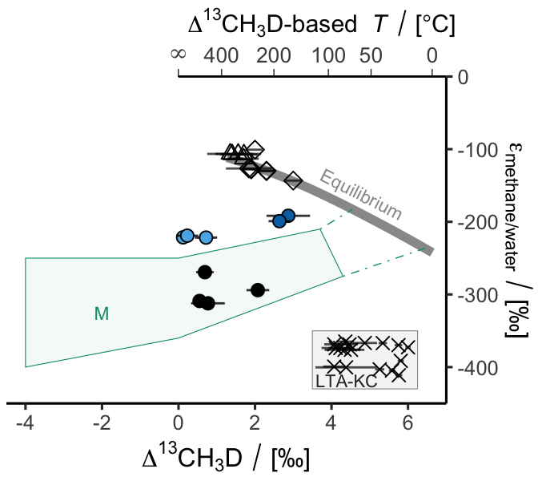

```r
# Set coordinates of origin fields after Wang et al. (2015)
microbial_capCD <- data.frame(
  x = c(4.3, 3.7, 0, -4, -4, 0),
  y = c(-275, -210, -250, -250, -400, -360)
)

abiotic_kidd_creek_capCD <- data.frame(
  x = c(3.5, 6.25, 6.25, 3.5),
  y = c(-350, -350, -430, -430)
)

# create plot
eps_CH4_H2O_cap13CH3D_plot <-  ggplot() +

  # Equilibrium curve
  geom_smooth(data = eq_curve_wang_DF, aes(
    y = epsCH4_H2O_permil,
    x = cap13CH3D_temp, se=FALSE), color = "grey60", size = 2, linetype = "solid") +

  # origin fields
  geom_polygon(data = microbial_capCD, aes(x=x, y=y), fill = microbial_color, alpha = microbial_opacity, color = microbial_color, size = .2) +
  geom_polygon(data = abiotic_kidd_creek_capCD, aes(x=x, y=y), alpha=.1, fill = "#999999", color = "#999999", size = .2) +

  # microbial extension
  geom_segment(aes(
    x = 3.7,
    xend = as.numeric(eq_curve_wang_DF %>% filter(temp_C == 70) %>% select(cap13CH3D_temp)),
    y = -210,
    yend = as.numeric(eq_curve_wang_DF %>% filter(temp_C == 70) %>% select(epsCH4_H2O_permil))
    ), color = microbial_color, linetype = "dotdash", size = .25, alpha = 1) +

  geom_segment(aes(
    x = 4.3,
    xend = as.numeric(eq_curve_wang_DF %>% filter(temp_C == 5) %>% select(cap13CH3D_temp)),
    y = -275,
    yend = as.numeric(eq_curve_wang_DF %>% filter(temp_C == 5) %>% select(epsCH4_H2O_permil))
    ), color = microbial_color, linetype = "dotdash", size = .25, alpha = 1) +

  # origin field labels
  annotate("text", x = 4.4, y = -418, size = 2.9, label = "LTA-KC", color = "grey20") +
  annotate("text", x = -2, y= -325, size = 3, label = "M", color = microbial_color) +
  annotate("text", x = 4.8, y= -162, size = 3, angle = -27, label = "Equilibrium", color = "grey60") +

  # Plot MIT data
  # error bars
  geom_errorbarh(data = data_clumps, aes(
    xmin = cap13CH3D_permil_MIT - cap13CH3D_unc_permil_MIT,
    xmax = cap13CH3D_permil_MIT + cap13CH3D_unc_permil_MIT,
    y = eps_CH4_H2O_permil_MIT), alpha = 0.8, height = 0) +
  # points
  geom_point(data = data_clumps, aes(
    y = eps_CH4_H2O_permil_MIT,
    x = cap13CH3D_permil_MIT,
    shape = site,
    fill = sampling_site), alpha = 1, size = 2.5) +

  # Plot UCLA data
  # error bars
  geom_errorbarh(data = data_clumps, aes(
    xmin = cap13CH3D_permil_UCLA - cap13CH3D_unc_permil_UCLA,
    xmax = cap13CH3D_permil_UCLA + cap13CH3D_unc_permil_UCLA,
        y = eps_CH4_H2O_permil_UCLA), alpha = 0.8, height = 0) +
  # points
  geom_point(data = data_clumps, aes(
    y = eps_CH4_H2O_permil_UCLA,
    x = cap13CH3D_permil_UCLA,
    shape = site,
    fill = sampling_site), alpha = 1, size = 2.5) +

  # Plot lit data
  # error bars
  geom_errorbarh(data = data_clumps_lit, aes(
    xmin = cap13CH3D_permil - cap13CH3D_unc_permil,
    xmax = cap13CH3D_permil + cap13CH3D_unc_permil,
    y = eps_CH4_H2O_permil), alpha = 0.7, height = 0) +
  # points
  geom_point(data = data_clumps_lit, aes(
    y = eps_CH4_H2O_permil,
    x = cap13CH3D_permil,
    shape = site), alpha = 1, size = 2.5) +

  # axis styling
  scale_y_continuous(expand = c(0,0), name = latex2exp::TeX("$\\epsilon_{methane/water}\\,/\\,\\[\U2030\\]$"), sec.axis = dup_axis(labels = NULL, name = NULL), position = "right") +
  scale_x_continuous(limits = c(-4.5, 7), expand = c(0,0), name = latex2exp::TeX("$\\Delta^{13}CH_{3}D\\,/\\,\\[\U2030\\]$"), breaks = c(-4, -2, 0, 2, 4, 6)) +

  # symbol styling
  scale_shape_manual(values = shapes_all_sites_named) +
  scale_fill_manual(values = fill_4_wells_named, name = "well") +

  # temperature axis ticks
  annotate("point", x = temp_axis_wang_DF$cap13CH3D_temp[1], y = 5.5, size = 1.5, shape = 108) +
  annotate("point", x = temp_axis_wang_DF$cap13CH3D_temp[2], y = 5.5, size = 1.5, shape = 108) +
  annotate("point", x = temp_axis_wang_DF$cap13CH3D_temp[3], y = 5.5, size = 1.5, shape = 108) +
  annotate("point", x = temp_axis_wang_DF$cap13CH3D_temp[4], y = 5.5, size = 1.5, shape = 108) +
  annotate("point", x = temp_axis_wang_DF$cap13CH3D_temp[5], y = 5.5, size = 1.5, shape = 108) +
  annotate("point", x = 0, y = 5.5, size = 1.5, shape = 108)+

  # temperature axis labels
  annotate("text", x = temp_axis_wang_DF$cap13CH3D_temp[1], y= 30, size = 3.5, label = temp_axis_wang_DF$temp_C[1], color = "gray30") +
  annotate("text", x = temp_axis_wang_DF$cap13CH3D_temp[2], y= 30, size = 3.5, label = temp_axis_wang_DF$temp_C[2], color = "gray30") +
  annotate("text", x = temp_axis_wang_DF$cap13CH3D_temp[3], y= 30, size = 3.5, label = temp_axis_wang_DF$temp_C[3], color = "gray30") +
  annotate("text", x = temp_axis_wang_DF$cap13CH3D_temp[4], y= 30, size = 3.5, label = temp_axis_wang_DF$temp_C[4], color = "gray30") +
  annotate("text", x = temp_axis_wang_DF$cap13CH3D_temp[5], y= 30, size = 3.5, label = temp_axis_wang_DF$temp_C[5], color = "gray30") +
  annotate("text", x = 0, y= 30, size = 4, label = latex2exp::TeX("$\\infty$"), color = "gray30") +
  annotate("text", y = 75, x= 3.75, size = 4, label = latex2exp::TeX("$\\Delta^{13}CH_{3}D-based\\;\\textit{T}\\,/\\,\\[ \\degree C\\]$")) +

  geom_segment(aes(x=0, xend=7, y=0, yend=0))+

  # design
  theme_classic(base_size = 12) +
  theme(
  axis.line.y.left = element_blank(),
  legend.position = "none",
  axis.ticks.y.left = element_blank(),
  plot.margin = margin(36, 0, 0, 0, "pt")
  ) +
  coord_cartesian(ylim = c(-450, 0), clip = "off")

# print plot
eps_CH4_H2O_cap13CH3D_plot
```

Plot $\Delta^{13}\text{CH}_3\text{D}$ (Y) vs. $\epsilon_{\text{CH}_4/\text{H}_2\text{O}}$ (X)

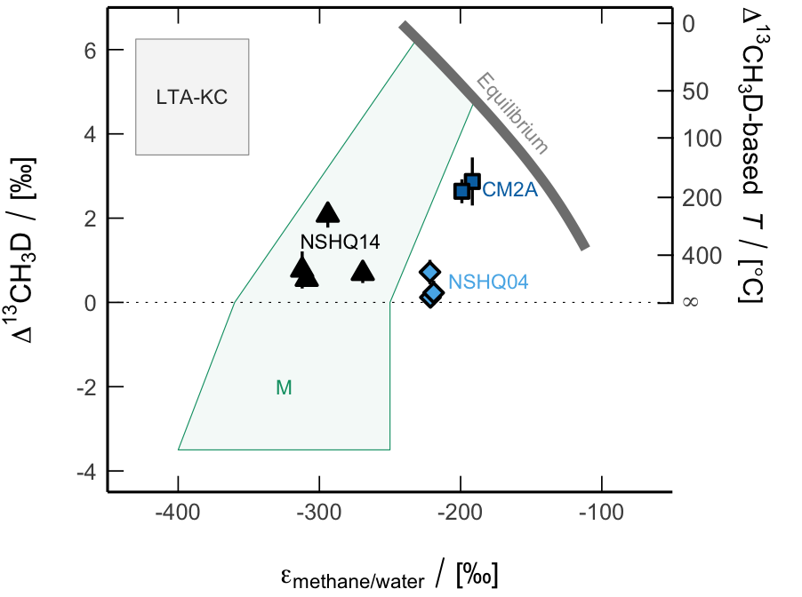

```r
# Set coordinates of origin fields after Wang et al. (2015)
microbial_capCD_wang <- data.frame(
  y = c(6.3, 4.8, 0, -3.5, -3.5, 0, 6.3),
  x = c(-230, -190, -250, -250, -400, -360, -230)
)

abiotic_kidd_creek_capCD_wang <- data.frame(
  y = c(3.5, 6.25, 6.25, 3.5),
  x = c(-350, -350, -430, -430)
)

# create plot
cap13CH3D_eps_CH4_H2O_plot <-  ggplot() +

  # plot origin fields
  geom_polygon(data = microbial_capCD_wang, aes(x=x, y=y), fill = microbial_color, alpha=.05, color = microbial_color, size = .2)+
  geom_polygon(data = abiotic_kidd_creek_capCD_wang, aes(x=x, y=y), alpha=.1, fill = "#999999", color = "#999999", size = .2) +
  annotate("text", y = 4.9, x= -390, size = 3, label = "LTA-KC", color = "grey20") +
  annotate("text", y = -2, x= -325, size = 3, label = "M", color = microbial_color) +
  annotate("text", y = 4.5, x = -162, size = 3, angle = -49, label = "Equilibrium", color = "grey60") +

  # equilibrium curve
  geom_smooth(data = eq_curve_wang_DF, aes(
    x = epsCH4_H2O_permil,
    y = cap13CH3D_temp, se=FALSE),  color = "grey50", size = 2, linetype = "solid")+
  # 0 ∆13CHD line
  geom_hline(yintercept = 0, linetype = "dotted", color = "black", size = 0.2)+

  # Plot MIT data
  geom_pointrange(data = data_clumps, aes(
    x = eps_CH4_H2O_permil_MIT,
    y = cap13CH3D_permil_MIT,
    ymin = cap13CH3D_permil_MIT - cap13CH3D_unc_permil_MIT,
    ymax = cap13CH3D_permil_MIT + cap13CH3D_unc_permil_MIT,
    fill = sampling_site,
    shape = sampling_site), size=.6, alpha = 1)+

  # Plot UCLA data
  geom_pointrange(data = data_clumps, aes(
    x = eps_CH4_H2O_permil_UCLA,
    y = cap13CH3D_permil_UCLA,
    ymin = cap13CH3D_permil_UCLA - cap13CH3D_unc_permil_UCLA,
    ymax = cap13CH3D_permil_UCLA + cap13CH3D_unc_permil_UCLA,
    fill = sampling_site,
    shape = sampling_site), size=.6, alpha = 1)+

  # axes styling
  scale_x_continuous(limits = c(-450, 50), expand = c(0,0), name = latex2exp::TeX("$\\epsilon_{methane/water} \\, / \\, \\[ \U2030 \\]$"), sec.axis = dup_axis(labels = NULL, name = NULL))+
  scale_y_continuous(limits = c(-4.5, 7), expand = c(0,0), name = latex2exp::TeX("$\\Delta^{13}CH_{3}D\\, / \\, \\[ \U2030 \\]"), breaks = c(-4, -2, 0, 2, 4, 6))+
  # symbol styling
  scale_fill_manual(values = fill_4_wells_named)+
  scale_shape_manual(values = shapes_fills)+

  # create temperature axis
  annotate("point", y = temp_axis_wang_DF$cap13CH3D_temp[1], x= -54.5, size = 3.8, shape = 95)+
  annotate("point", y = temp_axis_wang_DF$cap13CH3D_temp[2], x= -54.5, size = 3.8, shape = 95)+
  annotate("point", y = temp_axis_wang_DF$cap13CH3D_temp[3], x= -54.5, size = 3.8, shape = 95)+
  annotate("point", y = temp_axis_wang_DF$cap13CH3D_temp[4], x= -54.5, size = 3.8, shape = 95)+
  annotate("point", y = temp_axis_wang_DF$cap13CH3D_temp[5], x= -54.5, size = 3.8, shape = 95)+
  annotate("point", y = 0, x= -54.5, size = 3.8, shape = 95)+
  annotate("text", y = temp_axis_wang_DF$cap13CH3D_temp[1], x= -43, size = 3.6, label = temp_axis_wang_DF$temp_C[1], hjust = 0, color = "gray30")+
  annotate("text", y = temp_axis_wang_DF$cap13CH3D_temp[2], x= -43, size = 3.6, label = temp_axis_wang_DF$temp_C[2], hjust = 0, color = "gray30")+
  annotate("text", y = temp_axis_wang_DF$cap13CH3D_temp[3], x= -43, size = 3.6, label = temp_axis_wang_DF$temp_C[3], hjust = 0, color = "gray30")+
  annotate("text", y = temp_axis_wang_DF$cap13CH3D_temp[4], x= -43, size = 3.6, label = temp_axis_wang_DF$temp_C[4], hjust = 0, color = "gray30")+
  annotate("text", y = temp_axis_wang_DF$cap13CH3D_temp[5], x= -43, size = 3.6, label = temp_axis_wang_DF$temp_C[5], hjust = 0, color = "gray30")+
  annotate("text", y = 0, x= -43, size = 3.6, label = latex2exp::TeX("$\\infty$"), hjust = 0, color = "gray30")+
  annotate("text", y = 3.5, x = 8, size = 4, label = latex2exp::TeX("$\\Delta^{13}CH_{3} D-based\\;\\textit{T} \\, / \\, \\[ \\degree C \\]$"), angle=270) +

  # well labels
  annotate("text", y = 0.5, x= -180, size = 3, label = "NSHQ04", color = "#56B4E9")+
  annotate("text", y = 2.7, x= -165, size = 3, label = "CM2A", color = "#0072B2")+
  annotate("text", y = 1.45, x= -285, size = 3, label = "NSHQ14", color = "#000000")+

  # add right side y-axis
    geom_segment(aes(x = -50, xend = -50, y = 7, yend = 0))+

  # design
  theme_classic(base_size = 12)+
  theme(
    axis.ticks.length=unit(-0.24, "cm"),
    axis.ticks = element_line(colour = "black", size = 0.3),
    axis.text.x = element_text(margin = margin(t=0.4, r=0.4, b=0.4, l=0.4, unit = "cm")),
    axis.text.y = element_text(margin = margin(t=0.4, r=0.4, b=0.4, l=0.4, unit = "cm")),
    axis.ticks.y.right = element_blank(),
    plot.margin = margin(10,55, 1, 1, "pt"),
    legend.position = "none",
    axis.line.x = element_line(),
    axis.line.y.left = element_line()
    ) +
  guides(color = FALSE)+
  coord_cartesian(xlim = c(-450, -50), clip = "off")

# print plot
cap13CH3D_eps_CH4_H2O_plot
```

## 8.2 $\Delta^{13}\text{CH}_3\text{D}$ vs. $\Delta^{12}\text{CH}_2\text{D}_2$

### 8.2.1 Prepare data

Select Oman well samples for which $\Delta^{12}\text{CH}_2\text{D}_2$ was analyzed

```r
# get data with ∆12CH2D2 analyses
data_12CH2D2 <- data %>% filter(!is.na(cap12CH2D2_permil_UCLA)) %>%  select(sampling_site, cap13CH3D_permil_UCLA, cap13CH3D_unc_permil_UCLA, cap12CH2D2_permil_UCLA, cap12CH2D2_unc_permil_UCLA, site)

# print
data_12CH2D2
```

| sampling_site | cap13CH3D_permil_UCLA | cap13CH3D_unc_permil_UCLA | cap12CH2D2_permil_UCLA | cap12CH2D2_unc_permil_UCLA | site |
| --- | --- | --- | --- | --- | --- |
| CM2A | 2.638 | 0.284 | -1.267 | 0.886 | Oman/UAE |
| NSHQ04 | 0.229 | 0.288 | -24.502 | 0.944 | Oman/UAE |
| NSHQ14 | 2.074 | 0.298 | -0.204 | 1.358 | Oman/UAE |

Set up data for proper legend rendering

```r
# add in samples without cap12CH2D2 just so they will be in the legend for the capDD summary figure
non_DD_sites_empty_DF <- data_literature %>% distinct(site)

data_clumps_lit_all_sites <- data_clumps_lit %>% bind_rows(non_DD_sites_empty_DF)

# add factor levels to the data so that sites will be listed in order in legend
data_clumps_lit_all_sites$site <- factor(data_clumps_lit_all_sites$site, levels = c("Oman/UAE", "Chimaera", "Philippines", "Greece", "Mid-Cayman Rise", "Lost City", "Ashadze II", "Kidd Creek", "Sabatier reaction 70˚C to 90˚C"))
```

### 8.2.2 Plot

Generate equilibrium curves

```r
eq_curve_Young <- c(0, 5, 50, 70, 100, 150, 200, 250, 300, 350, 400, 450, 500, 600, 700, 800, 900, 1000, 2000, 3000, 5000) # create a vector of temperatures in Celsius for the equilibrium curve
eq_curve_Young_DF <- as.data.frame(eq_curve_Young) # convert vector to data frame
eq_curve_Young_DF <- eq_curve_Young_DF %>% rename(temp_C = eq_curve_Young) # rename
eq_curve_Young_DF <- eq_curve_Young_DF %>% mutate(cap_13CH3D_permil = 1000*log(1+0.0355502*(1/(temp_C+273.15))-433.038*(1/(temp_C+273.15))^2+1270210*(1/(temp_C+273.15))^3-594804000*(1/(temp_C+273.15))^4+119663000000*(1/(temp_C+273.15))^5-9072300000000*(1/(temp_C+273.15))^6)) # calculate ∆13CH3D as function of T using eqn from Young et al. (2017)
eq_curve_Young_DF <- eq_curve_Young_DF %>% mutate(cap_12CH2D2_permil = 1000*log(1+0.183798*(1/(temp_C+273.15))-785.483*(1/(temp_C+273.15))^2+1056280*(1/(temp_C+273.15))^3+93730700*(1/(temp_C+273.15))^4-89194800000*(1/(temp_C+273.15))^5+9901730000000*(1/(temp_C+273.15))^6)) # calculate ∆12CH2D2 as function of T using eqn from Young et al. (2017)
```

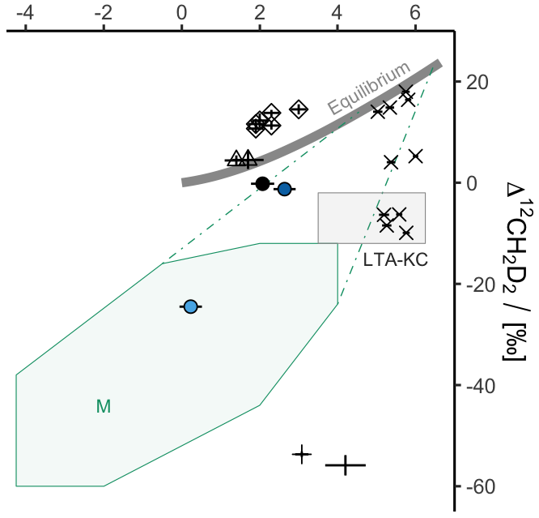

```r
# set origin fields after Young et al. (2017)
microbial_capDD <- data.frame(
  x = c(-4.25, -4.25, -0.5, .75, 2, 4, 4, 2, -2),
  y = c(-60, -38, -16, -14, -12, -12, -24, -44, -60)
)

high_temp_eq_capDD <- data.frame(
  x = c(1, 3, 3, 1),
  y = c(4, 9, 5, 0)
)

abiotic_kidd_creek_capDD <- data.frame(
  x = c(3.5, 6.25, 6.25, 3.5),
  y = c(-2, -2, -12, -12)
)

# create plot
cap12CH2D2_cap13CH3D_plot <-
  ggplot() +

  # add equilibrium curve
  geom_smooth(data = eq_curve_Young_DF, aes(
    x = cap_13CH3D_permil,
    y = cap_12CH2D2_permil,
    se=FALSE), color = "grey60", size = 2)+

  # origin fields

  # microbial
    geom_polygon(data = microbial_capDD, aes(x=x, y=y), fill = microbial_color, alpha = microbial_opacity, color = microbial_color, size = .2)+

  # microbial extension
    geom_segment(aes(
      x = -0.5,
      xend = as.numeric(eq_curve_Young_DF %>% filter(temp_C == 70) %>% select(cap_13CH3D_permil)),
      y = -16,
      yend = as.numeric(eq_curve_Young_DF %>% filter(temp_C == 70) %>% select(cap_12CH2D2_permil))
      ), color = microbial_color, linetype = "dotdash", size = .25, alpha = 1) +

    geom_segment(aes(
      x = 4,
      xend = as.numeric(eq_curve_Young_DF %>% filter(temp_C == 5) %>% select(cap_13CH3D_permil)),
      y = -24,
      yend = as.numeric(eq_curve_Young_DF %>% filter(temp_C == 5) %>% select(cap_12CH2D2_permil))
      ), color = microbial_color, linetype = "dotdash", size = .25, alpha = 1) +

  # low T abiotic kinetic
    geom_polygon(data = abiotic_kidd_creek_capDD, aes(x=x, y=y), alpha=.1, fill = "#999999", color = "#999999", size = .2)+
      annotate("text", x = 5.5, y= -15, size = 3, label = "LTA-KC", color = "grey20")+
      annotate("text", x = -2, y= -44, size = 3, label = "M", color = microbial_color)+
      annotate("text", x = 4.8, y = 19, size = 3, angle = 30, label = "Equilibrium", color = "grey60")+

  # plot literature data

  # error bars
    geom_errorbarh(data = data_clumps_lit,
      aes(
      y = cap12CH2D2_permil,
      xmin = cap13CH3D_permil - cap13CH3D_unc_permil,
      xmax = cap13CH3D_permil + cap13CH3D_unc_permil), height = 0, show_guide = FALSE) +

    geom_errorbar(data = data_clumps_lit,
      aes(
      x = cap13CH3D_permil,
      ymin = cap12CH2D2_permil - cap12CH2D2_unc_permil,
      ymax = cap12CH2D2_permil + cap12CH2D2_unc_permil), width = 0, show_guide = FALSE) +

  # points
    geom_point(data = data_clumps_lit_all_sites,
      aes(
      x = cap13CH3D_permil,
      y = cap12CH2D2_permil,
      shape = site), size = 2.5) +

  # Plot Oman well data

  # error bars
    geom_errorbarh(data = data_clumps,
      aes(
      y = cap12CH2D2_permil_UCLA,
      xmin = cap13CH3D_permil_UCLA - cap13CH3D_unc_permil_UCLA,
      xmax = cap13CH3D_permil_UCLA + cap13CH3D_unc_permil_UCLA), height = 0, show_guide = FALSE) +

    geom_errorbar(data = data_clumps,
      aes(
      x = cap13CH3D_permil_UCLA,
      ymin = cap12CH2D2_permil_UCLA - cap12CH2D2_unc_permil_UCLA,
      ymax = cap12CH2D2_permil_UCLA + cap12CH2D2_unc_permil_UCLA), width = 0, show_guide = FALSE) +

    geom_point(data = data_clumps,
      aes(
      x = cap13CH3D_permil_UCLA,
      y = cap12CH2D2_permil_UCLA,
      fill = sampling_site,
      shape = site), size = 2.5) +

  # axes styling
  scale_x_continuous(limits = c(-4.5, 7), expand = c(0,0), name = latex2exp::TeX("$\\Delta^{13}CH_{3}D\\, / \\, \\[ \U2030 \\]"), breaks = c(-4, -2, 0, 2, 4, 6), sec.axis = dup_axis()) +
  scale_y_continuous(limits = c(-65, 30), expand = c(0,0), name = latex2exp::TeX("$\\Delta^{12}CH_{2}D_2\\, / \\, \\[ \U2030 \\]"), breaks = c(-60, -40, 0, -20, 20, 40), sec.axis = dup_axis(name = NULL), position = "right") +

  # symbol styling
  scale_shape_manual(values = shapes_all_sites_named, guide = guide_legend(order = 1), name = "sample site") +
  scale_color_manual(values = cbPalette_water_types, name = "water type (this study)", guide = guide_legend(order = 2)) +
  scale_fill_manual(values = fill_4_wells_named, name = "well", guide = guide_legend(order = 3)) +

  # design
  theme_classic(base_size=12)+
  theme(
    panel.grid = element_blank(),
    legend.position = "none",
    legend.background = element_blank(),
    axis.ticks.x = element_line(),
    axis.title.x = element_blank(),
    axis.text.y.right = element_text(),
    axis.text.y.left = element_blank(),
    axis.ticks.y.left = element_blank(),
    axis.ticks.x.bottom = element_blank(),
    axis.text.x.top = element_text(),
    axis.text.x.bottom = element_blank(),
    axis.line.x.bottom = element_blank(),
    axis.line.y.left = element_blank(),
    plot.margin = margin(0, 0, 0, 0, "pt"),
    legend.box = "horizontal"
  )

# print plot
cap12CH2D2_cap13CH3D_plot
```

### 8.2.3 Extract shape legend

Create dummy plot from which to extract shape legend

```r
# create plot
adapted_young_ea_2017_shape_leg_plot <-
  ggplot() +

  # plot literature data
  geom_point(data = data_clumps_lit_all_sites,
    aes(
    x = cap13CH3D_permil,
    y = cap12CH2D2_permil,
    shape = site), size = 2.5) +

  # plot Oman well data
  geom_point(data = data_clumps,
    aes(
    x = cap13CH3D_permil_UCLA,
    y = cap12CH2D2_permil_UCLA,
    shape = site), size = 2.5) +

  # symbology styling
  scale_shape_manual(values = shapes_all_sites_named, guide = guide_legend(order = 1, label.hjust = 0), name = "sample site", na.translate = FALSE, labels = unname(latex2exp::TeX(c("Oman/UAE", "Philippines", "Mid-Cayman Rise", "Lost City", "Ashadze II", "Kidd Creek", "Sabatier reaction 70$\\,\\degree$C to 90$\\,\\degree$C"))))+

  # design
  theme_classic(base_size=12)
```

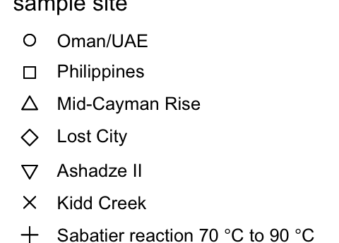

```r
# extract shape legend
leg_shape <- get_legend(adapted_young_ea_2017_shape_leg_plot)

# make shape legend
leg_shape_plot <- plot_grid(leg_shape
)

# print shape legend
leg_shape_plot
```

# 9 Alkanes $\delta^{13}$C plot

## 9.1 Prepare data

```r
# create data frame of CH4, C2H6, and C3H8 d13C data
data_alkanes_d13C <- data %>% filter(!is.na(C2H6_d13C_permil_VPDB)) %>% select(sampling_site, year_sampled, depth_fluid_intake_mbct, CH4_d13C_permil_VPDB_CUB, CH4_d13C_unc_permil_CUB, CH4_d13C_permil_VPDB_MIT, CH4_d13C_unc_permil_MIT, C2H6_d13C_permil_VPDB, C2H6_d13C_unc_permil, C3H8_d13C_permil_VPDB, C3H8_d13C_unc_permil)

# print
data_alkanes_d13C
```

| sampling_site | year_sampled | depth_fluid_intake_mbct | CH4_d13C_permil_VPDB_CUB | CH4_d13C_unc_permil_CUB | CH4_d13C_permil_VPDB_MIT | CH4_d13C_unc_permil_MIT | C2H6_d13C_permil_VPDB | C2H6_d13C_unc_permil | C3H8_d13C_permil_VPDB | C3H8_d13C_unc_permil |
| --- | --- | --- | --- | --- | --- | --- | --- | --- | --- | --- |
| NSHQ14 | 2017 | 85 | 0.2 | 0.6 | -0.08 | 0.05 | -6 | 0.6 | 3.3 | 0.6 |

Gather alkane $\delta^{13}\text{C}$ data so it can be plotted

```r
# gather data making a column for the compound
data_alkanes_d13C_gathered <- data_alkanes_d13C  %>% select(-depth_fluid_intake_mbct) %>% gather("compound_lab", "d13C_permil_VPDB", -sampling_site, -year_sampled, -CH4_d13C_unc_permil_CUB, -CH4_d13C_unc_permil_MIT, -C2H6_d13C_unc_permil, -C3H8_d13C_unc_permil)

# make a column that gives the # of C atoms in the compound based on the compounds chemcal formula
data_alkanes_d13C_gathered  <- data_alkanes_d13C_gathered %>% mutate(C_atoms = case_when(
str_detect(compound_lab, "CH") == TRUE ~ 1,
str_detect(compound_lab, "C2") == TRUE ~ 2,
str_detect(compound_lab, "C3") == TRUE ~ 3
))

# make another column for the uncertainty of each d13C analysis
data_alkanes_d13C_gathered  <- data_alkanes_d13C_gathered %>% mutate(uncertainty_d13C_permil = case_when(
compound_lab == "CH4_d13C_permil_VPDB_CUB" ~ CH4_d13C_unc_permil_CUB,
compound_lab == "CH4_d13C_permil_VPDB_MIT" ~ CH4_d13C_unc_permil_MIT,
compound_lab == "C2H6_d13C_permil_VPDB" ~ C2H6_d13C_unc_permil,
compound_lab == "C3H8_d13C_permil_VPDB" ~ C3H8_d13C_unc_permil
))

# select only the most relevant columns
data_alkanes_d13C_gathered <- data_alkanes_d13C_gathered %>% select(sampling_site, year_sampled, C_atoms, compound_lab, d13C_permil_VPDB, uncertainty_d13C_permil)

# print
data_alkanes_d13C_gathered
```

| sampling_site | year_sampled | C_atoms | compound_lab | d13C_permil_VPDB | uncertainty_d13C_permil |
| --- | --- | --- | --- | --- | --- |
| NSHQ14 | 2017 | 1 | CH4_d13C_permil_VPDB_CUB | 0.20 | 0.60 |
| NSHQ14 | 2017 | 1 | CH4_d13C_permil_VPDB_MIT | -0.08 | 0.05 |
| NSHQ14 | 2017 | 2 | C2H6_d13C_permil_VPDB | -6.00 | 0.60 |
| NSHQ14 | 2017 | 3 | C3H8_d13C_permil_VPDB | 3.30 | 0.60 |

Add a site and sample type to Oman well data so that it is compatible for plotting with literature data

```r
data_alkanes_d13C_gathered <- data_alkanes_d13C_gathered %>% mutate(site = "Oman/UAE", sample_type = "vent/well fluid")
```

Get literature data

```r
# get relevant data for C1-C5 alkane analyses
data_alkanes_d13C_lit <- data_literature %>% filter(!is.na(C2H6_d13C_permil_VPDB)) %>% filter(!is.na(C2H6_d13C_permil_VPDB)) %>% select(site, Sample, sample_type, CH4_d13C_permil_VPDB, C2H6_d13C_permil_VPDB, C3H8_d13C_permil_VPDB,  n_C4H10_d13C_permil_VPDB, n_C5H12_d13C_permil_VPDB)

# print
data_alkanes_d13C_lit
```

| site | Sample | sample_type | CH4_d13C_permil_VPDB | C2H6_d13C_permil_VPDB | C3H8_d13C_permil_VPDB | n_C4H10_d13C_permil_VPDB | n_C5H12_d13C_permil_VPDB |
| --- | --- | --- | --- | --- | --- | --- | --- |
| Ashadze II | NA | vent/well fluid | -8.7 | -2.0 | 8.3 | 10.0 | NA |
| Oman/UAE | 1b | vent/well fluid | -12.0 | -11.4 | NA | NA | NA |
| Philippines | NSS-02 | rock crushing | -3.0 | -0.9 | NA | NA | NA |
| Philippines | NSS-04 | rock crushing | -2.8 | -1.2 | NA | NA | NA |
| Mid-Cayman Rise | ALV 620-3C | rock crushing | -14.0 | -12.5 | NA | NA | NA |
| Mid-Cayman Rise | ALV 620-5-1 | rock crushing | -4.4 | 0.7 | NA | NA | NA |
| Mid-Cayman Rise | ALV 621-3-1 | rock crushing | -7.9 | -10.6 | NA | NA | NA |
| Mid-Cayman Rise | J2-612-IGT2 | vent/well fluid | -15.6 | -12.9 | -9.8 | NA | NA |
| Mid-Cayman Rise | J2-616-IGT8 | vent/well fluid | -15.3 | -12.3 | NA | NA | NA |
| Mid-Cayman Rise | J2-617-IGT4 | vent/well fluid | -15.8 | -13.2 | -10.8 | NA | NA |

[output cut: 24 more lines]

As previously done for Oman well data, gather literature data by compound for plotting purposes

```r
# select most relevant data from literature
data_alkanes_d13C_lit <- data_alkanes_d13C_lit %>%  select(site, Sample, sample_type, CH4_d13C_permil_VPDB, C2H6_d13C_permil_VPDB, C3H8_d13C_permil_VPDB,  n_C4H10_d13C_permil_VPDB, n_C5H12_d13C_permil_VPDB)

# gather by compound
data_alkanes_d13C_gathered_lit <- data_alkanes_d13C_lit %>% gather("compound", "d13C_permil_VPDB", -site, -Sample, -sample_type)

# assign number of C atoms per molecule based on the compound formula
data_alkanes_d13C_gathered_lit <- data_alkanes_d13C_gathered_lit %>% mutate(C_atoms = case_when(
str_detect(compound, "CH4") == TRUE ~ 1,
str_detect(compound, "C2H6") == TRUE ~ 2,
str_detect(compound, "C3H8") == TRUE ~ 3,
str_detect(compound, "C4H10") == TRUE ~ 4,
str_detect(compound, "C5H12") == TRUE ~ 5
))

# print
data_alkanes_d13C_gathered_lit
```

| site | Sample | sample_type | compound | d13C_permil_VPDB | C_atoms |
| --- | --- | --- | --- | --- | --- |
| Ashadze II | NA | vent/well fluid | CH4_d13C_permil_VPDB | -8.7 | 1 |
| Oman/UAE | 1b | vent/well fluid | CH4_d13C_permil_VPDB | -12.0 | 1 |
| Philippines | NSS-02 | rock crushing | CH4_d13C_permil_VPDB | -3.0 | 1 |
| Philippines | NSS-04 | rock crushing | CH4_d13C_permil_VPDB | -2.8 | 1 |
| Mid-Cayman Rise | ALV 620-3C | rock crushing | CH4_d13C_permil_VPDB | -14.0 | 1 |
| Mid-Cayman Rise | ALV 620-5-1 | rock crushing | CH4_d13C_permil_VPDB | -4.4 | 1 |
| Mid-Cayman Rise | ALV 621-3-1 | rock crushing | CH4_d13C_permil_VPDB | -7.9 | 1 |
| Mid-Cayman Rise | J2-612-IGT2 | vent/well fluid | CH4_d13C_permil_VPDB | -15.6 | 1 |
| Mid-Cayman Rise | J2-616-IGT8 | vent/well fluid | CH4_d13C_permil_VPDB | -15.3 | 1 |
| Mid-Cayman Rise | J2-617-IGT4 | vent/well fluid | CH4_d13C_permil_VPDB | -15.8 | 1 |

[output cut: 160 more lines]

## 9.2 Plot

### 9.2.1 Plot data

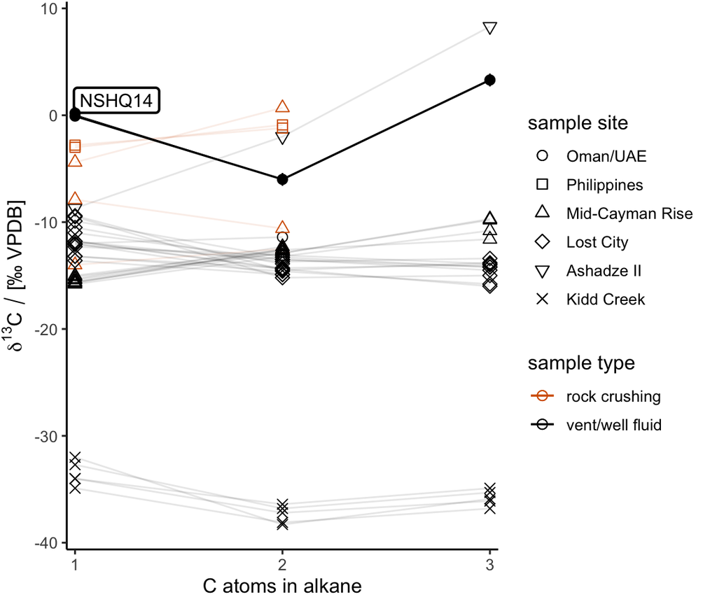

```r
# create plot
alkanes_d13C_oman_wells_and_lit_plot <- ggplot() +

  # Add line segments connecting NSHQ14 data points
  geom_segment(mapping = aes(x = 1, xend = 2, y = as.numeric(data_alkanes_d13C_gathered %>% filter(C_atoms == 1) %>% summarize(mean_d13C = mean(d13C_permil_VPDB))), yend = as.numeric(data_alkanes_d13C_gathered %>% filter(C_atoms == 2) %>% select(d13C_permil_VPDB))), linetype= "solid", color = "black", size = 0.2) +
  geom_segment(mapping = aes(x = 2, xend = 3, y = as.numeric(data_alkanes_d13C_gathered %>% filter(C_atoms == 2) %>% select(d13C_permil_VPDB)), yend = as.numeric(data_alkanes_d13C_gathered %>% filter(C_atoms == 3) %>% select(d13C_permil_VPDB))), linetype= "solid", color = "black", size = 0.2) +

  # Add NSHQ14 label
  annotate("label", label = "NSHQ14", x = 1.2, y = 1.4, label.size = 0.7) +

  # Plot literature data
  # lines
  geom_line(data = data_alkanes_d13C_gathered_lit %>% filter(C_atoms < 4),
    mapping =  aes(
    x = C_atoms,
    y = as.numeric(d13C_permil_VPDB),
    color = sample_type,
    group = Sample), alpha = 0.1) +

  # points
  geom_point(data = data_alkanes_d13C_gathered_lit %>% filter(C_atoms < 4),
    mapping =  aes(
    x = C_atoms,
    y = as.numeric(d13C_permil_VPDB),
    shape = site,
    color = sample_type), size = 2.5) +

  # Plot Oman well data
  # lines
  geom_line(data = data_alkanes_d13C_gathered %>% filter(C_atoms < 4),
    mapping =  aes(
    x = C_atoms,
    y = d13C_permil_VPDB,
    color = sample_type), alpha = 1, size = .6) +

  # error bars
  geom_linerange(data = data_alkanes_d13C_gathered,
    mapping =  aes(
    x = C_atoms,
    ymax = d13C_permil_VPDB + uncertainty_d13C_permil,
    ymin = d13C_permil_VPDB - uncertainty_d13C_permil,
    color = sample_type), show.legend = FALSE) +
  # points
  geom_point(data = data_alkanes_d13C_gathered,
    mapping =  aes(
    x = C_atoms,
    y = d13C_permil_VPDB,
    shape = site,
    color = sample_type,
    fill = sampling_site), size = 2.5) +

  # symbol styling
  scale_shape_manual(name = "sample site",  values = shapes_all_sites_named, guide = guide_legend(order = 1)) +
    scale_fill_manual(values = fill_4_wells_named, guide = FALSE) +
    scale_color_manual(values =  color_rock_crush_named, name = "sample type", guide = guide_legend(nrow = 1, order = 3)) +
    guides(color = guide_legend(override.aes=list(shape=21))) +

  # axis styling
  scale_x_continuous(name = "C atoms in alkane", breaks = c(1,2,3), expand = expand_scale(add = c(0.04)))+
  scale_y_continuous(name = latex2exp::TeX("$\\delta ^{13}C$$\\,$/$\\,$\\lbrack$$‰ VPDB$\\rbrack$"))+

  # design
  theme_classic(base_size = 12) +
  theme(
    panel.grid.major.x = element_blank(),
    panel.grid.minor.x = element_blank(),
    panel.grid.major.y = element_blank(),
    panel.grid.minor.y = element_blank(),
    # legend.position = "bottom",
    # legend.direction = "vertical",
    plot.margin = margin(1, 3, 0, 1, "pt")
    )

# print plot
alkanes_d13C_oman_wells_and_lit_plot
```

### 9.2.2 Extract color legend

Create dummy plot

```r
# create dummy plot from which to extract color legend
alkanes_d13C_this_study_and_lit_for_col_leg_plot <- ggplot() +

  # Add line segments connecting NSHQ14 data points
  geom_segment(mapping = aes(x = 1, xend = 2, y = as.numeric(data_alkanes_d13C_gathered %>% filter(C_atoms == 1) %>% summarize(mean_d13C = mean(d13C_permil_VPDB))), yend = as.numeric(data_alkanes_d13C_gathered %>% filter(C_atoms == 2) %>% select(d13C_permil_VPDB))), linetype= "solid", color = "black", size = 0.2) +
  geom_segment(mapping = aes(x = 2, xend = 3, y = as.numeric(data_alkanes_d13C_gathered %>% filter(C_atoms == 2) %>% select(d13C_permil_VPDB)), yend = as.numeric(data_alkanes_d13C_gathered %>% filter(C_atoms == 3) %>% select(d13C_permil_VPDB))), linetype= "solid", color = "black", size = 0.2) +

  # Add NSHQ14 label
  annotate("label", label = "NSHQ14", x = 1.35, y = 1) +

  # Plot literature data
  geom_point(data = data_alkanes_d13C_gathered_lit %>% filter(C_atoms < 4),
    mapping =  aes(
    x = C_atoms,
    y = as.numeric(d13C_permil_VPDB),
    color = sample_type), size = 2.5) +

  # Plot Oman well data
  # error bars
  geom_linerange(data = data_alkanes_d13C_gathered,
    mapping =  aes(
    x = C_atoms,
    ymax = d13C_permil_VPDB + uncertainty_d13C_permil,
    ymin = d13C_permil_VPDB - uncertainty_d13C_permil,
    color = sample_type), show.legend = FALSE) +
  # points
  geom_point(data = data_alkanes_d13C_gathered,
    mapping =  aes(
    x = C_atoms,
    y = d13C_permil_VPDB,
    # shape = site,
    color = sample_type,
    fill = sampling_site)) +

  # symbol styling
  scale_shape_manual(name = "sample site",  values = shapes_all_sites_named, guide = guide_legend(order = 1)) +
    scale_fill_manual(values = fill_4_wells_named, guide = FALSE) +
    scale_color_manual(values =  color_rock_crush_named, name = "sample type", guide = guide_legend(nrow = 1, order = 3)) +
    guides(color = guide_legend(override.aes=list(shape=21))) +

  # axis styling
  scale_x_continuous(name = "C atoms in alkane", breaks = c(1,2,3))+
  scale_y_continuous(name = latex2exp::TeX("$\\delta ^{13}C$$\\,$/$\\,$\\lbrack$$‰ VPDB$\\rbrack$"))+

  # design
  theme_classic(base_size = 12) +
  theme(
    panel.grid.major.x = element_blank(),
    panel.grid.minor.x = element_blank(),
    panel.grid.major.y = element_blank(),
    panel.grid.minor.y = element_blank(),
    legend.position = "bottom",
    legend.direction = "vertical"
    )
```

Extract color legend

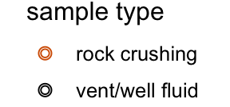

```r
# show just color legend
leg_color <- get_legend(alkanes_d13C_this_study_and_lit_for_col_leg_plot)

leg_color_plot <- plot_grid(leg_color
)

leg_color_plot
```